# Personal_Loan_Campaign_FINAL-JULY30

### Treating the outliers

We observed the presence of outlier values in the Credit Card Spending feature

```python
df = treat_outliers_all(df, ["CreditCard_Spending_sqrt"])
```

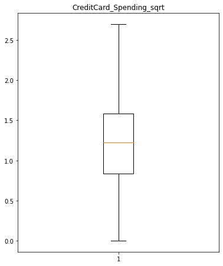

```python
# let's look at box plot to see if outliers have been treated or not
plt.figure(figsize=(20, 30))

for i, variable in enumerate(["CreditCard_Spending_sqrt"]):
    plt.subplot(5, 4, i + 1)
    plt.boxplot(df[variable], whis=1.5)
    plt.tight_layout()
    plt.title(variable)

plt.show()
```

### Data Normalization

Normalizing scales of numeric features for better modeling performance.

Differences in scales across input variables may increase the difficulty of the problem being modeled - a model with large weight values is often unstable, meaning it might suffer from poor performance during learning as well as sensitivity to input values thereby resulting in higher generalization error

```python
df[["Age", "Experience", "Income_sqrt", "CreditCard_Spending_sqrt", "Family_Size"]].describe().T
```

|  | count | mean | std | min | 25% | 50% | 75% | max |
| --- | --- | --- | --- | --- | --- | --- | --- | --- |
| Age | 5000.0 | 45.338400 | 11.463166 | 23.000000 | 35.000000 | 45.000000 | 55.000000 | 67.000000 |
| Experience | 5000.0 | 20.119600 | 11.440484 | 0.000000 | 10.000000 | 20.000000 | 30.000000 | 43.000000 |
| Income_sqrt | 5000.0 | 8.166221 | 2.662416 | 2.828427 | 6.244998 | 8.000000 | 9.899495 | 14.966630 |
| CreditCard_Spending_sqrt | 5000.0 | 1.250626 | 0.598898 | 0.000000 | 0.836660 | 1.224745 | 1.581139 | 2.697857 |
| Family_Size | 5000.0 | 2.396400 | 1.147663 | 1.000000 | 1.000000 | 2.000000 | 3.000000 | 4.000000 |

```python
from sklearn.preprocessing import MinMaxScaler
min_max_scaler = MinMaxScaler()
df[["Age", "Experience", "Income_sqrt", "CreditCard_Spending_sqrt", "Family_Size"]] = min_max_scaler.fit_transform(df[["Age", "Experience", "Income_sqrt", "CreditCard_Spending_sqrt", "Family_Size"]])
```

```python
df[["Age", "Experience", "Income_sqrt", "CreditCard_Spending_sqrt", "Family_Size"]].describe().T
```

|  | count | mean | std | min | 25% | 50% | 75% | max |
| --- | --- | --- | --- | --- | --- | --- | --- | --- |
| Age | 5000.0 | 0.507691 | 0.260526 | 0.0 | 0.272727 | 0.500000 | 0.727273 | 1.0 |
| Experience | 5000.0 | 0.467898 | 0.266058 | 0.0 | 0.232558 | 0.465116 | 0.697674 | 1.0 |
| Income_sqrt | 5000.0 | 0.439752 | 0.219342 | 0.0 | 0.281473 | 0.426058 | 0.582547 | 1.0 |
| CreditCard_Spending_sqrt | 5000.0 | 0.463563 | 0.221990 | 0.0 | 0.310120 | 0.453970 | 0.586072 | 1.0 |
| Family_Size | 5000.0 | 0.465467 | 0.382554 | 0.0 | 0.000000 | 0.333333 | 0.666667 | 1.0 |

#### Observation

- Non-categorical features normalized successfully - this was done primarily in order to stabilize logistic regression model performance

# Building the Predictive Models

### Goal of the model

- To recap, the goal is to build a model that will help the marketing department identify the potential customers who have a higher probability of accepting a personal loan offer

For the predictive model it is important to remember the following in terms of target variable classification:

- True Positive: customer classified by the model as “will accept personal loan offer” and who had in fact “accepted offer” in reality.
- False Positive: customer classified by the model as “will accept personal loan offer” but who actually “did not accept offer” in reality.
- True Negative: customer classified by the model as “will not accept personal loan offer” and who in fact “did not accept offer” in reality.
- False Negative: customer classified by the model as “will not accept personal loan offer” but who had actually “accepted offer” in reality.

###### Precision:

- Of those classified as “Will accept personal loan offer,” what proportion actually did?
- True positive / (True positive + False positive)

###### Recall:

- Of those that in fact “accepted the personal loan offer,” what proportion were classified that way?
- True positive / (True positive + False negative)

##### Better models have higher values for precision and recall.

For example, 94% precision would mean that almost all customers identified as “will accept the offer” do in fact and 97% recall would mean almost all customers who “accepted the offer” were identified as such.

If the model performed with 95% precision but 50% recall this would mean that when it identifies someone as “will accept offer,” it’s largely correct, but it mislabels as “will not accept the offer” half of those who did in fact later “accepted offer”.

### Precision, Recall, F1 scores

Within any one model, we can decide to emphasize precision, recall or a balance of the two which is provided by F1 scores - the decision comes down to context.

### Model can make wrong predictions as:

1. Predicting a customer will accept the personal loan offer but customer will not.
2. Predicting a customer will not accept the personal loan offer but customer will.

### Which case is more important?

- Given that the marketing team commissioned a model to enhance target marketing and increase success ratio, we attempted to maximize precision (i.e., minimize false positives) while not losing sight of the F1 performance which can serve as a means of comparison and verification for the strongest predictors of the model

## Supervised Learning Model 1: Logistic Regression

### Logistic Regression (with Sklearn library)

```python
X = df.drop(["Personal_Loan", "ID", "ZIPCode"], axis=1)
Y = df["Personal_Loan"]

# creating dummy variables
X = pd.get_dummies(X, drop_first=True) #Converting categorical variable CA_Region into dummy variables.

# splitting in training and test set
X_train, X_test, y_train, y_test = train_test_split(X, Y, test_size=0.3, random_state=1)
```

```python
#Making sure distribution of target variable values in the train and test data is the same as for the original dataset
print("Distribution of target variable values in original dataset:\n", df.Personal_Loan.value_counts(normalize=True))
print("Distribution of target variable values in train dataset:\n", y_train.value_counts(normalize=True))
print("Distribution of target variable values in test dataset:\n", y_test.value_counts(normalize=True))
```

```
Distribution of target variable values in original dataset:
 0    0.904
1    0.096
Name: Personal_Loan, dtype: float64
Distribution of target variable values in train dataset:
 0    0.905429
1    0.094571
Name: Personal_Loan, dtype: float64
Distribution of target variable values in test dataset:
 0    0.900667
1    0.099333
Name: Personal_Loan, dtype: float64
```

#### Observation:

- As desired, we observe that the target variable is distributed at similar levels in the original, train, and test datasets

```python
# There are different solvers available in Sklearn logistic regression: we will use the newton-cg solver
model = LogisticRegression(solver="newton-cg", random_state=1)
lg = model.fit(X_train, y_train)
```

```python
# predicting on training set
y_pred_train = lg.predict(X_train)
```

```python
print("Training set performance:")
print("Accuracy:", accuracy_score(y_train, y_pred_train))
print("Precision:", precision_score(y_train, y_pred_train))
print("Recall:", recall_score(y_train, y_pred_train))
print("F1:", f1_score(y_train, y_pred_train))
```

```
Training set performance:
Accuracy: 0.9551428571428572
Precision: 0.881578947368421
Recall: 0.6072507552870091
F1: 0.7191413237924865
```

```python
# predicting on the test set
y_pred_test = lg.predict(X_test)
```

```python
print("Test set performance:")
print("Accuracy:", accuracy_score(y_test, y_pred_test))
print("Precision:", precision_score(y_test, y_pred_test))
print("Recall:", recall_score(y_test, y_pred_test))
print("F1:", f1_score(y_test, y_pred_test))
```

```
Test set performance:
Accuracy: 0.9466666666666667
Precision: 0.896551724137931
Recall: 0.5234899328859061
F1: 0.6610169491525425
```

**Observations**

- Accuracy gives us the fraction of times a prediction was right. In the case of training and testing data this prediction (both for true positives and true negatives) was 95.5% and 94.7% accurate, respectively
- Precision gives us the percentage of true positives out of all values that were predicted to be positive. In the case of training data, this percentage was 88.2%; for the testing data it was 89.7%
- Recall is also called the true positive rate, it calculates the percentage of true positives predicted out of all actual positive values (meaning out of true positives and false negatives). In this case, recall for the training data was 60.7% and for test data, 52.3%.
- F1 gives us a measure of both the goodness of precision and recall. When precision and recall are both 1, F1 will be 1 as well - no error in the model. In this case, the F1 percentage in the training data was 71.9% and in the test data 66.1%
- Overall, the performance measures reflected in the training and test data are comparable. The greatest difference being between recall scores

### Logistic Regression (with statsmodels library)

```python
# defining a function to compute different metrics to check performance of a classification model built using statsmodels
def model_performance_classification_statsmodels(
    model, predictors, target, threshold=0.5
):
    """
    Function to compute different metrics to check classification model performance

    model: classifier
    predictors: independent variables
    target: dependent variable
    threshold: threshold for classifying the observation as class 1
    """

    # checking which probabilities are greater than threshold
    pred_temp = model.predict(predictors) > threshold
    # rounding off the above values to get classes
    pred = np.round(pred_temp)

    acc = accuracy_score(target, pred)  # to compute Accuracy
    recall = recall_score(target, pred)  # to compute Recall
    precision = precision_score(target, pred)  # to compute Precision
    f1 = f1_score(target, pred)  # to compute F1-score

    # creating a dataframe of metrics
    df_perf = pd.DataFrame(
        {"Accuracy": acc, "Recall": recall, "Precision": precision, "F1": f1,},
        index=[0],
    )

    return df_perf
```

```python
# defining a function to plot the confusion_matrix of a classification model


def confusion_matrix_statsmodels(model, predictors, target, threshold=0.5):
    """
    To plot the confusion_matrix with percentages

    model: classifier
    predictors: independent variables
    target: dependent variable
    threshold: threshold for classifying the observation as class 1
    """
    y_pred = model.predict(predictors) > threshold
    cm = confusion_matrix(target, y_pred)
    labels = np.asarray(
        [
            ["{0:0.0f}".format(item) + "\n{0:.2%}".format(item / cm.flatten().sum())]
            for item in cm.flatten()
        ]
    ).reshape(2, 2)

    plt.figure(figsize=(6, 4))
    sns.heatmap(cm, annot=labels, fmt="")
    plt.ylabel("True label")
    plt.xlabel("Predicted label")
```

```python
X = df.drop(["Personal_Loan", "ID", "ZIPCode"], axis=1)
Y = df["Personal_Loan"]


# creating dummy variables
X = pd.get_dummies(X, drop_first=True)

# adding constant
X = sm.add_constant(X)

# splitting in training and test set
X_train, X_test, y_train, y_test = train_test_split(X, Y, test_size=0.3, random_state=1)
```

```python
logit = sm.Logit(y_train, X_train.astype(float))
lg = logit.fit(
    disp=False
)  # setting disp=False will remove the information on number of iterations

print(lg.summary())
```

```
                           Logit Regression Results
==============================================================================
Dep. Variable:          Personal_Loan   No. Observations:                 3500
Model:                          Logit   Df Residuals:                     3478
Method:                           MLE   Df Model:                           21
Date:                Fri, 30 Jul 2021   Pseudo R-squ.:                  0.6312
Time:                        11:36:41   Log-Likelihood:                -403.97
converged:                       True   LL-Null:                       -1095.5
Covariance Type:            nonrobust   LLR p-value:                4.162e-280
=========================================================================================================
                                            coef    std err          z      P>|z|      [0.025      0.975]
---------------------------------------------------------------------------------------------------------
const                                   -17.0222      0.986    -17.258      0.000     -18.955     -15.089
Age                                      -0.9322      3.325     -0.280      0.779      -7.450       5.585
Experience                                1.2234      3.248      0.377      0.706      -5.142       7.589
Family_Size                               2.2707      0.290      7.817      0.000       1.701       2.840
Education                                 1.7971      0.146     12.312      0.000       1.511       2.083
Securities_Account                       -1.2008      0.385     -3.122      0.002      -1.955      -0.447
CD_Account                                3.9081      0.418      9.358      0.000       3.090       4.727
Online_Banking                           -0.6604      0.198     -3.332      0.001      -1.049      -0.272
Other_CreditCard                         -1.2036      0.258     -4.668      0.000      -1.709      -0.698
Income_sqrt                              14.9104      0.916     16.285      0.000      13.116      16.705
CreditCard_Spending_sqrt                  1.9732      0.467      4.223      0.000       1.058       2.889
Mortgage_Holder                           0.2211      0.199      1.108      0.268      -0.170       0.612
CA_Region_Inland_Empire                  -0.1213      0.673     -0.180      0.857      -1.440       1.197
CA_Region_Los_Angeles_County             -0.0873      0.339     -0.257      0.797      -0.752       0.577
CA_Region_North_Coast                     0.0893      0.888      0.101      0.920      -1.651       1.830
CA_Region_Northern_San_Joaquin_Valley    -1.7301      1.828     -0.947      0.344      -5.312       1.852
CA_Region_Orange_County                  -0.2319      0.451     -0.514      0.607      -1.115       0.651
CA_Region_San_Diego_Imperial             -0.0133      0.392     -0.034      0.973      -0.782       0.755
CA_Region_San_Francisco_Bay_Area         -0.0538      0.320     -0.168      0.867      -0.682       0.574
CA_Region_Southern_San_Joaquin_Valley     0.6161      0.768      0.802      0.423      -0.890       2.122
CA_Region_Superior_California            -0.2225      0.435     -0.512      0.609      -1.075       0.630
CA_Region_Unknown                         1.1770      1.011      1.164      0.244      -0.804       3.158
=========================================================================================================

Possibly complete quasi-separation: A fraction 0.18 of observations can be
perfectly predicted. This might indicate that there is complete
quasi-separation. In this case some parameters will not be identified.
```

```python
print("Training performance:")
model_performance_classification_statsmodels(lg, X_train, y_train)
```

```
Training performance:
```

|  | Accuracy | Recall | Precision | F1 |
| --- | --- | --- | --- | --- |
| 0 | 0.957143 | 0.664653 | 0.849421 | 0.745763 |

**Observations**

- Negative values of the coefficient shows that probability of customer signing up for a personal loan decreases with the increase of corresponding attribute value.
- Positive values of the coefficient show that that probability of customer signing up for a personal loan increases with the increase of corresponding attribute value.
- p-value of a variable indicates if the variable is significant or not. If we consider the significance level to be 0.05 (5%), then any variable with a p-value less than 0.05 would be considered significant.
- But these variables might contain multicollinearity, which will affect the p-values.
- We will have to remove multicollinearity from the data to get reliable coefficients and p-values.
- There are different ways of detecting (or testing) multi-collinearity, one such way is the Variation Inflation Factor.

### Additional Information on VIF

- **Variance Inflation factor**: Variance inflation factors measure the inflation in the variances of the regression coefficients estimates due to collinearity that exist among the predictors. It is a measure of how much the variance of the estimated regression coefficient βk is "inflated" by the existence of correlation among the predictor variables in the model.
- General Rule of thumb: If VIF is 1 then there is no correlation among the kth predictor and the remaining predictor variables, and hence the variance of β̂k is not inflated at all. Whereas if VIF exceeds 5, we say there is moderate VIF and if it is 10 or exceeding 10, it shows signs of high multi-collinearity. But the purpose of the analysis should dictate which threshold to use.

```python
vif_series = pd.Series(
    [variance_inflation_factor(X_train.values, i) for i in range(X_train.shape[1])],
    index=X_train.columns,
    dtype=float,
)
print("Series before feature selection: \n\n{}\n".format(vif_series))
```

```
Series before feature selection:

const                                    34.225544
Age                                      95.805371
Experience                               95.782079
Family_Size                               1.029421
Education                                 1.114490
Securities_Account                        1.146511
CD_Account                                1.345520
Online_Banking                            1.044081
Other_CreditCard                          1.114773
Income_sqrt                               1.665156
CreditCard_Spending_sqrt                  1.584322
Mortgage_Holder                           1.006544
CA_Region_Inland_Empire                   1.272279
CA_Region_Los_Angeles_County              2.484406
CA_Region_North_Coast                     1.164508
CA_Region_Northern_San_Joaquin_Valley     1.056888
CA_Region_Orange_County                   1.579087
CA_Region_San_Diego_Imperial              1.857431
CA_Region_San_Francisco_Bay_Area          2.902354
CA_Region_Southern_San_Joaquin_Valley     1.130530
CA_Region_Superior_California             1.657063
CA_Region_Unknown                         1.069195
dtype: float64
```

#### Observations

- We observe a high mulitcollinearity in Age and Experience features, both VIF over 10
- We will drop Age first since it has the highest VIF

```python
X_train1 = X_train.drop(["Age"], axis=1,)
```

```python
vif_series1 = pd.Series(
    [variance_inflation_factor(X_train1.values, i) for i in range(X_train1.shape[1])],
    index=X_train1.columns,
    dtype=float,
)
print("Series after feature removal: \n\n{}\n".format(vif_series1))
```

```
Series after feature removal:

const                                    32.589043
Experience                                1.012761
Family_Size                               1.028983
Education                                 1.044942
Securities_Account                        1.146101
CD_Account                                1.344612
Online_Banking                            1.043959
Other_CreditCard                          1.114740
Income_sqrt                               1.660939
CreditCard_Spending_sqrt                  1.578159
Mortgage_Holder                           1.006398
CA_Region_Inland_Empire                   1.272279
CA_Region_Los_Angeles_County              2.484328
CA_Region_North_Coast                     1.164191
CA_Region_Northern_San_Joaquin_Valley     1.056879
CA_Region_Orange_County                   1.578378
CA_Region_San_Diego_Imperial              1.857197
CA_Region_San_Francisco_Bay_Area          2.901984
CA_Region_Southern_San_Joaquin_Valley     1.130530
CA_Region_Superior_California             1.655856
CA_Region_Unknown                         1.069061
dtype: float64
```

#### Observations

- None of the variables exhibit high multicollinearity now, so the values in the summary are reliable.
- Now let's move to removing the insignificant features (p-value>0.05).

```python
logit1 = sm.Logit(y_train, X_train1.astype(float))
lg1 = logit1.fit(disp=False)
print(lg1.summary())
print("Training performance:")
model_performance_classification_statsmodels(lg1, X_train1, y_train)
```

```
                           Logit Regression Results
==============================================================================
Dep. Variable:          Personal_Loan   No. Observations:                 3500
Model:                          Logit   Df Residuals:                     3479
Method:                           MLE   Df Model:                           20
Date:                Fri, 30 Jul 2021   Pseudo R-squ.:                  0.6312
Time:                        11:36:41   Log-Likelihood:                -404.01
converged:                       True   LL-Null:                       -1095.5
Covariance Type:            nonrobust   LLR p-value:                5.136e-281
=========================================================================================================
                                            coef    std err          z      P>|z|      [0.025      0.975]
---------------------------------------------------------------------------------------------------------
const                                   -17.0703      0.973    -17.547      0.000     -18.977     -15.164
Experience                                0.3182      0.348      0.914      0.361      -0.364       1.001
Family_Size                               2.2715      0.290      7.820      0.000       1.702       2.841
Education                                 1.7903      0.144     12.441      0.000       1.508       2.072
Securities_Account                       -1.1977      0.385     -3.114      0.002      -1.952      -0.444
CD_Account                                3.9102      0.417      9.366      0.000       3.092       4.728
Online_Banking                           -0.6591      0.198     -3.328      0.001      -1.047      -0.271
Other_CreditCard                         -1.2017      0.258     -4.663      0.000      -1.707      -0.697
Income_sqrt                              14.9311      0.913     16.357      0.000      13.142      16.720
CreditCard_Spending_sqrt                  1.9672      0.466      4.217      0.000       1.053       2.881
Mortgage_Holder                           0.2201      0.199      1.104      0.270      -0.171       0.611
CA_Region_Inland_Empire                  -0.1348      0.674     -0.200      0.841      -1.455       1.185
CA_Region_Los_Angeles_County             -0.0866      0.339     -0.255      0.798      -0.751       0.577
CA_Region_North_Coast                     0.0887      0.888      0.100      0.920      -1.651       1.828
CA_Region_Northern_San_Joaquin_Valley    -1.7549      1.837     -0.955      0.339      -5.355       1.845
CA_Region_Orange_County                  -0.2312      0.450     -0.513      0.608      -1.114       0.652
CA_Region_San_Diego_Imperial             -0.0115      0.392     -0.029      0.976      -0.779       0.756
CA_Region_San_Francisco_Bay_Area         -0.0544      0.320     -0.170      0.865      -0.682       0.573
CA_Region_Southern_San_Joaquin_Valley     0.6060      0.767      0.790      0.429      -0.897       2.109
CA_Region_Superior_California            -0.2258      0.434     -0.520      0.603      -1.077       0.626
CA_Region_Unknown                         1.1772      1.011      1.164      0.244      -0.804       3.159
=========================================================================================================

Possibly complete quasi-separation: A fraction 0.18 of observations can be
perfectly predicted. This might indicate that there is complete
quasi-separation. In this case some parameters will not be identified.
Training performance:
```

|  | Accuracy | Recall | Precision | F1 |
| --- | --- | --- | --- | --- |
| 0 | 0.957143 | 0.664653 | 0.849421 | 0.745763 |

#### Observations

- In the case of 'CA_Region', all the attributes have a high p-value which means these are not significant and therefore we can drop the complete variable.
- For other attributes present in the data, the p-values are high for only a few - we will drop them iteratively as sometimes p-values change after dropping a variable.

```python
X_train2 = X_train1.drop([
    "CA_Region_Inland_Empire",
    "CA_Region_Los_Angeles_County",
    "CA_Region_North_Coast",
    "CA_Region_Northern_San_Joaquin_Valley",
    "CA_Region_Orange_County",
    "CA_Region_San_Diego_Imperial",
    "CA_Region_San_Francisco_Bay_Area",
    "CA_Region_Southern_San_Joaquin_Valley",
    "CA_Region_Superior_California",
    "CA_Region_Unknown"], axis=1)
```

```python
logit2 = sm.Logit(y_train, X_train2.astype(float))
lg2 = logit2.fit()
print(lg2.summary())
print("Training performance:")
model_performance_classification_statsmodels(lg2, X_train2, y_train)
```

```
Optimization terminated successfully.
         Current function value: 0.115999
         Iterations 10
                           Logit Regression Results
==============================================================================
Dep. Variable:          Personal_Loan   No. Observations:                 3500
Model:                          Logit   Df Residuals:                     3489
Method:                           MLE   Df Model:                           10
Date:                Fri, 30 Jul 2021   Pseudo R-squ.:                  0.6294
Time:                        11:36:41   Log-Likelihood:                -406.00
converged:                       True   LL-Null:                       -1095.5
Covariance Type:            nonrobust   LLR p-value:                3.514e-290
============================================================================================
                               coef    std err          z      P>|z|      [0.025      0.975]
--------------------------------------------------------------------------------------------
const                      -17.0778      0.930    -18.358      0.000     -18.901     -15.255
Experience                   0.3089      0.346      0.894      0.372      -0.369       0.986
Family_Size                  2.2768      0.287      7.924      0.000       1.714       2.840
Education                    1.7810      0.143     12.470      0.000       1.501       2.061
Securities_Account          -1.2047      0.382     -3.151      0.002      -1.954      -0.455
CD_Account                   3.8968      0.412      9.453      0.000       3.089       4.705
Online_Banking              -0.6641      0.196     -3.390      0.001      -1.048      -0.280
Other_CreditCard            -1.2139      0.255     -4.764      0.000      -1.713      -0.715
Income_sqrt                 14.8471      0.904     16.430      0.000      13.076      16.618
CreditCard_Spending_sqrt     2.0117      0.459      4.385      0.000       1.113       2.911
Mortgage_Holder              0.2204      0.198      1.115      0.265      -0.167       0.608
============================================================================================

Possibly complete quasi-separation: A fraction 0.18 of observations can be
perfectly predicted. This might indicate that there is complete
quasi-separation. In this case some parameters will not be identified.
Training performance:
```

|  | Accuracy | Recall | Precision | F1 |
| --- | --- | --- | --- | --- |
| 0 | 0.955714 | 0.65861 | 0.838462 | 0.737733 |

#### Observation

- We observe p-values higher than the 0.05 level for Experience and Mortgage_Holder. We will drop Experience next and then re-examine the model

```python
X_train3 = X_train2.drop(["Experience"], axis=1)
```

```python
logit3 = sm.Logit(y_train, X_train3.astype(float))
lg3 = logit3.fit()
print(lg3.summary())
print("Training performance:")
model_performance_classification_statsmodels(lg3, X_train3, y_train)
```

```
Optimization terminated successfully.
         Current function value: 0.116113
         Iterations 10
                           Logit Regression Results
==============================================================================
Dep. Variable:          Personal_Loan   No. Observations:                 3500
Model:                          Logit   Df Residuals:                     3490
Method:                           MLE   Df Model:                            9
Date:                Fri, 30 Jul 2021   Pseudo R-squ.:                  0.6290
Time:                        11:36:41   Log-Likelihood:                -406.40
converged:                       True   LL-Null:                       -1095.5
Covariance Type:            nonrobust   LLR p-value:                4.108e-291
============================================================================================
                               coef    std err          z      P>|z|      [0.025      0.975]
--------------------------------------------------------------------------------------------
const                      -16.8520      0.888    -18.985      0.000     -18.592     -15.112
Family_Size                  2.2602      0.287      7.885      0.000       1.698       2.822
Education                    1.7728      0.142     12.472      0.000       1.494       2.051
Securities_Account          -1.2048      0.383     -3.147      0.002      -1.955      -0.454
CD_Account                   3.9179      0.413      9.497      0.000       3.109       4.727
Online_Banking              -0.6664      0.196     -3.405      0.001      -1.050      -0.283
Other_CreditCard            -1.2191      0.255     -4.783      0.000      -1.719      -0.720
Income_sqrt                 14.8013      0.900     16.455      0.000      13.038      16.564
CreditCard_Spending_sqrt     1.9654      0.455      4.317      0.000       1.073       2.858
Mortgage_Holder              0.2120      0.197      1.074      0.283      -0.175       0.599
============================================================================================

Possibly complete quasi-separation: A fraction 0.17 of observations can be
perfectly predicted. This might indicate that there is complete
quasi-separation. In this case some parameters will not be identified.
Training performance:
```

|  | Accuracy | Recall | Precision | F1 |
| --- | --- | --- | --- | --- |
| 0 | 0.956 | 0.65861 | 0.841699 | 0.738983 |

#### Observation

- P-value for Mortgage Holder continues to be greater than 0.05. We will drop it next.

```python
X_train4 = X_train3.drop(["Mortgage_Holder"], axis=1)
```

```python
logit4 = sm.Logit(y_train, X_train4.astype(float))
lg4 = logit4.fit()
print(lg4.summary())
print("Training performance:")
model_performance_classification_statsmodels(lg4, X_train4, y_train)
```

```
Optimization terminated successfully.
         Current function value: 0.116277
         Iterations 10
                           Logit Regression Results
==============================================================================
Dep. Variable:          Personal_Loan   No. Observations:                 3500
Model:                          Logit   Df Residuals:                     3491
Method:                           MLE   Df Model:                            8
Date:                Fri, 30 Jul 2021   Pseudo R-squ.:                  0.6285
Time:                        11:36:41   Log-Likelihood:                -406.97
converged:                       True   LL-Null:                       -1095.5
Covariance Type:            nonrobust   LLR p-value:                5.363e-292
============================================================================================
                               coef    std err          z      P>|z|      [0.025      0.975]
--------------------------------------------------------------------------------------------
const                      -16.7710      0.881    -19.031      0.000     -18.498     -15.044
Family_Size                  2.2633      0.287      7.892      0.000       1.701       2.825
Education                    1.7697      0.142     12.469      0.000       1.492       2.048
Securities_Account          -1.1922      0.382     -3.120      0.002      -1.941      -0.443
CD_Account                   3.9187      0.413      9.484      0.000       3.109       4.728
Online_Banking              -0.6621      0.196     -3.386      0.001      -1.045      -0.279
Other_CreditCard            -1.2202      0.255     -4.794      0.000      -1.719      -0.721
Income_sqrt                 14.7915      0.898     16.472      0.000      13.032      16.551
CreditCard_Spending_sqrt     1.9545      0.455      4.295      0.000       1.063       2.846
============================================================================================

Possibly complete quasi-separation: A fraction 0.17 of observations can be
perfectly predicted. This might indicate that there is complete
quasi-separation. In this case some parameters will not be identified.
Training performance:
```

|  | Accuracy | Recall | Precision | F1 |
| --- | --- | --- | --- | --- |
| 0 | 0.956286 | 0.65861 | 0.844961 | 0.740238 |

##### Observation

**Now no feature has p-value greater than 0.05, so we'll consider the features in *X_train4* as the final ones and *lg4* as final model.**

### Coefficient interpretations

- Coefficients of Family Size, Education, CD Account (having a certificate of deposit account at the bank), Income, and Credit Card Spending (average monthly credit card spending) are positive; an increase in these will lead to an increase in chances of a customer accepting the personal loan offered in the marketing campaign.
- Coefficients of Securities Account (having a securities account at the bank), Online Banking (using the bank's online banking facilities), and Other Credit Card (using a credit card issued by any other bank) are negative; an increase in these will lead to a decrease in chances of a customer accepting the personal loan offered in the marketing campaign.

### Converting coefficients to odds

- The coefficients of the logistic regression model are in terms of log(odd), to find the odds we have to take the exponential of the coefficients.
- Therefore, **odds = exp(b)**
- The percentage change in odds is given as **odds = (exp(b) - 1) * 100**

```python
# converting coefficients to odds
odds = np.exp(lg4.params)

# finding the percentage change
perc_change_odds = (np.exp(lg4.params) - 1) * 100

# removing limit from number of columns to display
pd.set_option("display.max_columns", None)

# adding the odds to a dataframe
pd.DataFrame({"Odds": odds, "Change_odd%": perc_change_odds}, index=X_train4.columns).T
```

|  | const | Family_Size | Education | Securities_Account | CD_Account | Online_Banking | Other_CreditCard | Income_sqrt | CreditCard_Spending_sqrt |
| --- | --- | --- | --- | --- | --- | --- | --- | --- | --- |
| Odds | 5.205374e-08 | 9.614529 | 5.869246 | 0.303542 | 50.333804 | 0.515777 | 0.295162 | 2.653741e+06 | 7.060109 |
| Change_odd% | -9.999999e+01 | 861.452855 | 486.924644 | -69.645798 | 4933.380358 | -48.422266 | -70.483814 | 2.653740e+08 | 606.010857 |

### Coefficient interpretations

- `Family Size`: Holding all other features constant a unit change in family size will increase the odds of a customer accepting a personal loan offer after the marketing campaign by 9.61 times or a 861.45% increase in odds.
- `Education`: Holding all other features constant a unit change in education will increase the odds of a customer accepting a personal loan offer after the marketing campaign by 5.87 times or a 486.92% increase in odds.
- `Securities Account`: The odds of a customer who has a securities account accepting the personal loan offer is 0.30 times less than a customer who does not have a securities account at the bank or 69.65% less odds of accepting the bank's personal loan offer than the customer who does not have a securities account.
- `CD Account`: The odds of a customer who has a CD account at the bank accepting the personal loan offer is 50.333804 times greater than a customer who does not have a CD account or 4933.38% greater odds of accepting the bank's personal loan offer than the customer who does not have a CD account.
- `Online Banking`: The odds of a customer who uses the bank's online facilities accepting the personal loan offer is 0.51 times less than a customer who does not use online banking or 48.42% less odds of accepting the bank's personal loan offer than the customer who does not make use of online banking.
- `Other Credit Card`: The odds of a customer who uses a credit card from any other bank accepting the personal loan offer is 0.30 times less than a customer who does not use another bank's credit card or 70.48% less odds of accepting the bank's personal loan offer than the customer who does not use another bank's credit card
- `Income`: Holding all other features constant a unit change in income will increase the odds of a customer accepting a personal loan offer after the marketing campaign by 2.65 x 10^6 times or a 2.65 x 10^8% increase in odds.
- `Credit Card Spending`: Holding all other features constant a unit change in credit card spending will increase the odds of a customer accepting a personal loan offer after the marketing campaign by 7.06 times or a 606.01% increase in odds.

#### Checking model performance on the training set

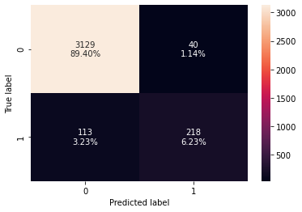

```python
# creating confusion matrix
confusion_matrix_statsmodels(lg4, X_train4, y_train)
```

```python
log_reg_model_train_perf = model_performance_classification_statsmodels(
    lg4, X_train4, y_train
)

print("Training performance:")
log_reg_model_train_perf
```

```
Training performance:
```

|  | Accuracy | Recall | Precision | F1 |
| --- | --- | --- | --- | --- |
| 0 | 0.956286 | 0.65861 | 0.844961 | 0.740238 |

#### ROC-AUC

- ROC-AUC on training set

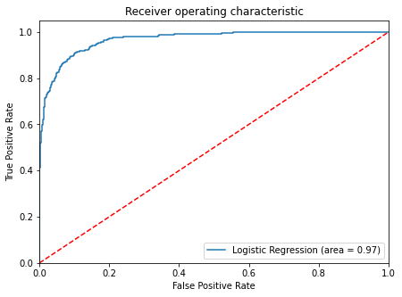

```python
logit_roc_auc_train = roc_auc_score(y_train, lg4.predict(X_train4))
fpr, tpr, thresholds = roc_curve(y_train, lg4.predict(X_train4))
plt.figure(figsize=(7, 5))
plt.plot(fpr, tpr, label="Logistic Regression (area = %0.2f)" % logit_roc_auc_train)
plt.plot([0, 1], [0, 1], "r--")
plt.xlim([0.0, 1.0])
plt.ylim([0.0, 1.05])
plt.xlabel("False Positive Rate")
plt.ylabel("True Positive Rate")
plt.title("Receiver operating characteristic")
plt.legend(loc="lower right")
plt.show()
```

### Model Performance Improvement

- Let's see if the precision score can be improved further, by changing the model threshold using AUC-ROC Curve.

### Optimal threshold using AUC-ROC curve

```python
# Optimal threshold as per AUC-ROC curve
# The optimal cut off would be where tpr is high and fpr is low
fpr, tpr, thresholds = roc_curve(y_train, lg4.predict(X_train4))

optimal_idx = np.argmax(tpr - fpr)
optimal_threshold_auc_roc = thresholds[optimal_idx]
print(optimal_threshold_auc_roc)
```

```
0.08891715248060887
```

#### Checking model performance on training set

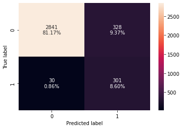

```python
# creating confusion matrix
confusion_matrix_statsmodels(
    lg4, X_train4, y_train, threshold=optimal_threshold_auc_roc
)
```

```python
# checking model performance for this model
log_reg_model_train_perf_threshold_auc_roc = model_performance_classification_statsmodels(
    lg4, X_train4, y_train, threshold=optimal_threshold_auc_roc
)
print("Training performance:")
log_reg_model_train_perf_threshold_auc_roc
```

```
Training performance:
```

|  | Accuracy | Recall | Precision | F1 |
| --- | --- | --- | --- | --- |
| 0 | 0.897714 | 0.909366 | 0.478537 | 0.627083 |

#### Observations

- Precision of model has substantially decreased while recall greatly improved
- Accuracy and F1 have also decreased
- Substantial increase in type I error (False Positives): from 1.14% to 9.37% - not ideal since we are trying to minimize type I error to maximize precision

#### Let's use Precision-Recall curve and see if we can find a better threshold

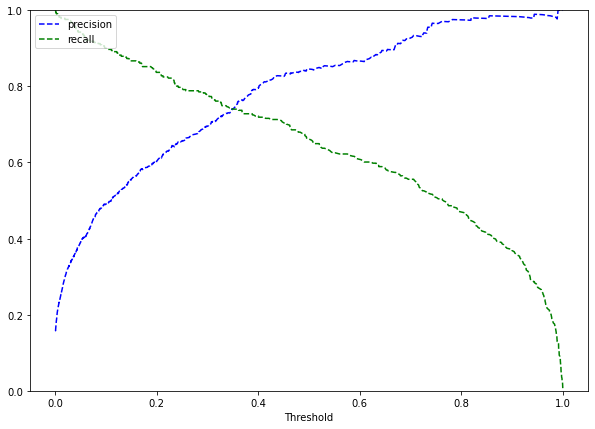

```python
y_scores = lg4.predict(X_train4)
prec, rec, tre = precision_recall_curve(y_train, y_scores,)


def plot_prec_recall_vs_tresh(precisions, recalls, thresholds):
    plt.plot(thresholds, precisions[:-1], "b--", label="precision")
    plt.plot(thresholds, recalls[:-1], "g--", label="recall")
    plt.xlabel("Threshold")
    plt.legend(loc="upper left")
    plt.ylim([0, 1])


plt.figure(figsize=(10, 7))
plot_prec_recall_vs_tresh(prec, rec, tre)
plt.show()
```

- At threshold around 0.38 we will get equal precision and recall but taking a step back and selecting value around 0.40 will provide higher precision which we are trying to maximize

```python
# setting the threshold
optimal_threshold_curve = 0.40
```

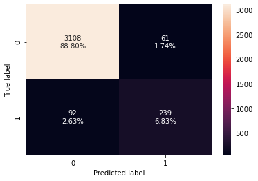

```python
# creating confusion matrix
confusion_matrix_statsmodels(lg4, X_train4, y_train, threshold=optimal_threshold_curve)
```

```python
log_reg_model_train_perf_threshold_curve = model_performance_classification_statsmodels(
    lg4, X_train4, y_train, threshold=optimal_threshold_curve
)
print("Training performance:")
log_reg_model_train_perf_threshold_curve
```

```
Training performance:
```

|  | Accuracy | Recall | Precision | F1 |
| --- | --- | --- | --- | --- |
| 0 | 0.956286 | 0.722054 | 0.796667 | 0.757528 |

#### Observations

- Model is performing well on training set.
- Compared to the default threshold of 0.50, the model with threshold set at 0.40 is performaing about the same in terms of accuracy though precision has decreased. Recall and F1 improved slightly with use of 0.40 threshold compared to 0.5 threshold

#### Now let's try to go higher than the default threshold of 0.50 and examine the results

```python
# setting the threshold
higher_threshold_curve1 = 0.60
higher_threshold_curve2 = 0.70
```

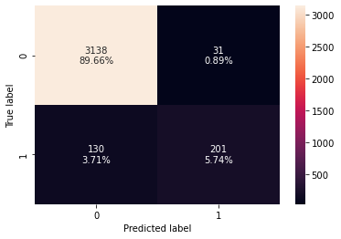

```python
# creating confusion matrix
confusion_matrix_statsmodels(lg4, X_train4, y_train, threshold=higher_threshold_curve1)
```

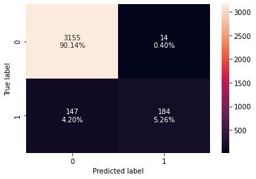

```python
# creating confusion matrix
confusion_matrix_statsmodels(lg4, X_train4, y_train, threshold=higher_threshold_curve2)
```

```python
log_reg_model_train_perf_higher_threshold_curve1 = model_performance_classification_statsmodels(
    lg4, X_train4, y_train, threshold=higher_threshold_curve1
)
print("Training performance:")
log_reg_model_train_perf_higher_threshold_curve1
```

```
Training performance:
```

|  | Accuracy | Recall | Precision | F1 |
| --- | --- | --- | --- | --- |
| 0 | 0.954 | 0.607251 | 0.866379 | 0.714032 |

```python
log_reg_model_train_perf_higher_threshold_curve2 = model_performance_classification_statsmodels(
    lg4, X_train4, y_train, threshold=higher_threshold_curve2
)
print("Training performance:")
log_reg_model_train_perf_higher_threshold_curve2
```

```
Training performance:
```

|  | Accuracy | Recall | Precision | F1 |
| --- | --- | --- | --- | --- |
| 0 | 0.954 | 0.555891 | 0.929293 | 0.695652 |

#### Observation

- Looking at thresholds higher than the 0.5 default precision keeps improving and recall decreasing

### Model Performance Summary

```python
# training performance comparison

models_train_comp_df = pd.concat(
    [
        log_reg_model_train_perf_threshold_auc_roc.T, #log_reg_model_train_perf_threshold_auc_roc
        log_reg_model_train_perf_threshold_curve.T, #log_reg_model_train_perf_threshold_curve
        log_reg_model_train_perf.T,#log_reg_model_train_perf
        log_reg_model_train_perf_higher_threshold_curve1.T,
        log_reg_model_train_perf_higher_threshold_curve2.T

    ],
    axis=1,
)
models_train_comp_df.columns = [
    "Logistic Regression-0.09 Threshold",
    "Logistic Regression-0.40 Threshold",
    "Logistic Regression-0.50 Threshold",
    "Logistic Regression-0.60 Threshold",
    "Logistic Regression-0.70 Threshold"
]

print("Training performance comparison:")
models_train_comp_df
```

```
Training performance comparison:
```

|  | Logistic Regression-0.09 Threshold | Logistic Regression-0.40 Threshold | Logistic Regression-0.50 Threshold | Logistic Regression-0.60 Threshold | Logistic Regression-0.70 Threshold |
| --- | --- | --- | --- | --- | --- |
| Accuracy | 0.897714 | 0.956286 | 0.956286 | 0.954000 | 0.954000 |
| Recall | 0.909366 | 0.722054 | 0.658610 | 0.607251 | 0.555891 |
| Precision | 0.478537 | 0.796667 | 0.844961 | 0.866379 | 0.929293 |
| F1 | 0.627083 | 0.757528 | 0.740238 | 0.714032 | 0.695652 |

### Let's check the performance on the test set

```python
X_test4 = X_test[X_train4.columns].astype(float)
```

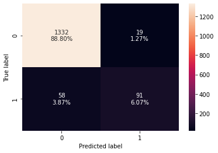

```python
# creating confusion matrix
confusion_matrix_statsmodels(lg4, X_test4, y_test)
```

```python
log_reg_model_test_perf = model_performance_classification_statsmodels(
    lg4, X_test4, y_test
)

print("Test performance:")
log_reg_model_test_perf
```

```
Test performance:
```

|  | Accuracy | Recall | Precision | F1 |
| --- | --- | --- | --- | --- |
| 0 | 0.948667 | 0.610738 | 0.827273 | 0.702703 |

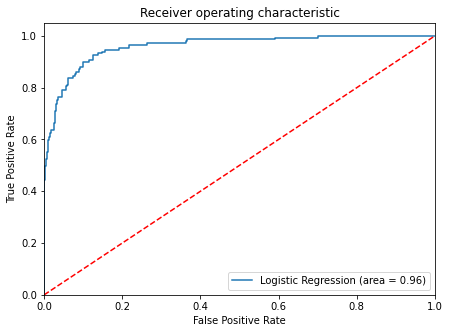

```python
logit_roc_auc_train = roc_auc_score(y_test, lg4.predict(X_test4))
fpr, tpr, thresholds = roc_curve(y_test, lg4.predict(X_test4))
plt.figure(figsize=(7, 5))
plt.plot(fpr, tpr, label="Logistic Regression (area = %0.2f)" % logit_roc_auc_train)
plt.plot([0, 1], [0, 1], "r--")
plt.xlim([0.0, 1.0])
plt.ylim([0.0, 1.05])
plt.xlabel("False Positive Rate")
plt.ylabel("True Positive Rate")
plt.title("Receiver operating characteristic")
plt.legend(loc="lower right")
plt.show()
```

**Using model with threshold=0.09**

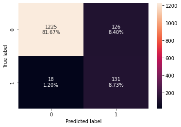

```python
# creating confusion matrix
confusion_matrix_statsmodels(lg4, X_test4, y_test, threshold=optimal_threshold_auc_roc)
```

```python
# checking model performance for this model
log_reg_model_test_perf_threshold_auc_roc = model_performance_classification_statsmodels(
    lg4, X_test4, y_test, threshold=optimal_threshold_auc_roc
)
print("Test performance:")
log_reg_model_test_perf_threshold_auc_roc
```

```
Test performance:
```

|  | Accuracy | Recall | Precision | F1 |
| --- | --- | --- | --- | --- |
| 0 | 0.904 | 0.879195 | 0.509728 | 0.64532 |

**Using model with threshold = 0.40**

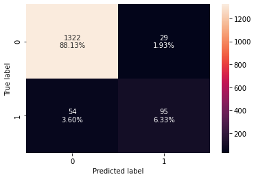

```python
# creating confusion matrix
confusion_matrix_statsmodels(lg4, X_test4, y_test, threshold=optimal_threshold_curve)
```

```python
log_reg_model_test_perf_threshold_curve = model_performance_classification_statsmodels(
    lg4, X_test4, y_test, threshold=optimal_threshold_curve
)
print("Test performance:")
log_reg_model_test_perf_threshold_curve
```

```
Test performance:
```

|  | Accuracy | Recall | Precision | F1 |
| --- | --- | --- | --- | --- |
| 0 | 0.944667 | 0.637584 | 0.766129 | 0.695971 |

**Using model with threshold = 0.60**

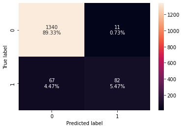

```python
# creating confusion matrix
confusion_matrix_statsmodels(lg4, X_test4, y_test, threshold=higher_threshold_curve1)
```

```python
log_reg_model_test_perf_higher_threshold_curve1 = model_performance_classification_statsmodels(
    lg4, X_test4, y_test, threshold=higher_threshold_curve1
)
print("Test performance:")
log_reg_model_test_perf_higher_threshold_curve1
```

```
Test performance:
```

|  | Accuracy | Recall | Precision | F1 |
| --- | --- | --- | --- | --- |
| 0 | 0.948 | 0.550336 | 0.88172 | 0.677686 |

**Using model with threshold = 0.70**

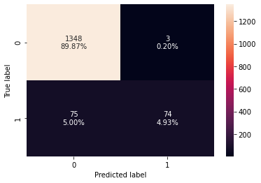

```python
# creating confusion matrix
confusion_matrix_statsmodels(lg4, X_test4, y_test, threshold=higher_threshold_curve2)
```

```python
log_reg_model_test_perf_higher_threshold_curve2 = model_performance_classification_statsmodels(
    lg4, X_test4, y_test, threshold=higher_threshold_curve2
)
print("Test performance:")
log_reg_model_test_perf_higher_threshold_curve2
```

```
Test performance:
```

|  | Accuracy | Recall | Precision | F1 |
| --- | --- | --- | --- | --- |
| 0 | 0.948 | 0.496644 | 0.961039 | 0.654867 |

### Model performance summary

```python
# training performance comparison

models_train_comp_df = pd.concat(
    [
        log_reg_model_train_perf_threshold_auc_roc.T,
        log_reg_model_train_perf_threshold_curve.T,
        log_reg_model_train_perf.T,
        log_reg_model_train_perf_higher_threshold_curve1.T,
        log_reg_model_train_perf_higher_threshold_curve2.T

    ],
    axis=1,
)
models_train_comp_df.columns = [
    "Logistic Regression-0.09 Threshold",
    "Logistic Regression-0.40 Threshold",
    "Logistic Regression-0.50 Threshold",
    "Logistic Regression-0.60 Threshold",
    "Logistic Regression-0.70 Threshold"
]

print("Training performance comparison:")
models_train_comp_df
```

```
Training performance comparison:
```

|  | Logistic Regression-0.09 Threshold | Logistic Regression-0.40 Threshold | Logistic Regression-0.50 Threshold | Logistic Regression-0.60 Threshold | Logistic Regression-0.70 Threshold |
| --- | --- | --- | --- | --- | --- |
| Accuracy | 0.897714 | 0.956286 | 0.956286 | 0.954000 | 0.954000 |
| Recall | 0.909366 | 0.722054 | 0.658610 | 0.607251 | 0.555891 |
| Precision | 0.478537 | 0.796667 | 0.844961 | 0.866379 | 0.929293 |
| F1 | 0.627083 | 0.757528 | 0.740238 | 0.714032 | 0.695652 |

```python
# test performance comparison

models_test_comp_df = pd.concat(
    [
        log_reg_model_test_perf_threshold_auc_roc.T,
        log_reg_model_test_perf_threshold_curve.T,
        log_reg_model_test_perf.T,
        log_reg_model_test_perf_higher_threshold_curve1.T,
        log_reg_model_test_perf_higher_threshold_curve2.T

    ],
    axis=1,
)
models_test_comp_df.columns = [
    "Logistic Regression-0.09 Threshold",
    "Logistic Regression-0.40 Threshold",
    "Logistic Regression-0.50 Threshold",
    "Logistic Regression-0.60 Threshold",
    "Logistic Regression-0.70 Threshold"
]

print("Test set performance comparison:")
models_test_comp_df
```

```
Test set performance comparison:
```

|  | Logistic Regression-0.09 Threshold | Logistic Regression-0.40 Threshold | Logistic Regression-0.50 Threshold | Logistic Regression-0.60 Threshold | Logistic Regression-0.70 Threshold |
| --- | --- | --- | --- | --- | --- |
| Accuracy | 0.904000 | 0.944667 | 0.948667 | 0.948000 | 0.948000 |
| Recall | 0.879195 | 0.637584 | 0.610738 | 0.550336 | 0.496644 |
| Precision | 0.509728 | 0.766129 | 0.827273 | 0.881720 | 0.961039 |
| F1 | 0.645320 | 0.695971 | 0.702703 | 0.677686 | 0.654867 |

### Conclusion

- To recap, the goal of this model building project is to develop a means to better predict, based on a set of characterisitcs of AllLife Bank's customers, which kind of customer would be more likely to accept the bank's marketing campaign offer for a personal loan.
- Toward that end, we have been able to build a model that can be used by the marketing team to predict customers more likely to accept the personal loan offer with a precision score of 0.83 on the test set at default threshold 0.5.
- Perhaps most indicative of the robust quality of the predictive model is the fact that it performs similarly in the training and test modes, **the most closely alligned threshold between training and test datasets being at the 0.5 default level**.
- The model's coefficients indicate that income, credit card spending, family size, education, and having a CD account at the bank all increase the odds of a customer accepting the bank's personal loan offer.
- Though with small odds, the model indicates that having a securities account at the bank, using its online banking facilities, as well as using a credit card from another bank decrease the chances that a customer will accept the personal loan offer.

### Business Recommendations

- Overall the bank should target customers with higher levels of income, credit card spending, education, larger family size (2 or more), and who hold a CD account at the bank
- We also emphasize, based on the model's predictions, that income, having a CD account, education, and credit card spending have the strongest impact at increasing the odds that a customer will accept a loan offer; meaning that the greater the income, credit card spending, and education, the greater the odds that the customer will accept the offer. Having a CD account also exerts a strong positive effect.
- More highly educated customers as well as those with higher income and credit card spending levels are also more likely to opt in for a loan - campaigns developed to specially address the needs of these customers, the model indicates, would yield higher conversion rates and gains for AllLife Bank
- An idea would also be to develop offers tailored to customers opening a CD account at the bank as well as existing CD account holders
- Another opportunity would be to tailor offers to customers who are married and/or have children

## Supervised Learning Model 2: Decision Trees

### Create dummies

```python
df1 = pd.get_dummies(df,columns=['CA_Region'], drop_first=True)
```

```python
#check dataset after dummies created
df1.info()
```

```
<class 'pandas.core.frame.DataFrame'>
RangeIndex: 5000 entries, 0 to 4999
Data columns (total 24 columns):
 #   Column                                 Non-Null Count  Dtype
---  ------                                 --------------  -----
 0   ID                                     5000 non-null   int64
 1   Age                                    5000 non-null   float64
 2   Experience                             5000 non-null   float64
 3   ZIPCode                                5000 non-null   int64
 4   Family_Size                            5000 non-null   float64
 5   Education                              5000 non-null   int64
 6   Personal_Loan                          5000 non-null   int64
 7   Securities_Account                     5000 non-null   int64
 8   CD_Account                             5000 non-null   int64
 9   Online_Banking                         5000 non-null   int64
```

[output cut: 16 more lines]

```python
# defining X and y variables
X = df1.drop(["Personal_Loan", "ID", "ZIPCode"], axis=1)
y = df1[["Personal_Loan"]]

print(X.head())
print(y.head())
```

```
        Age  Experience  Family_Size  Education  Securities_Account  \
0  0.045455    0.023256     1.000000          1                   1
1  0.500000    0.441860     0.666667          1                   1
2  0.363636    0.348837     0.000000          1                   0
3  0.272727    0.209302     0.000000          2                   0
4  0.272727    0.186047     1.000000          2                   0

   CD_Account  Online_Banking  Other_CreditCard  Income_sqrt  \
0           0               0                 0     0.343673
1           0               0                 0     0.247362
2           0               0                 0     0.040220
3           0               0                 0     0.590827
4           0               0                 1     0.319634

   CreditCard_Spending_sqrt  Mortgage_Holder  CA_Region_Inland_Empire  \
```

[output cut: 46 more lines]

```python
#Split Data
X_train, X_test, y_train, y_test = train_test_split(X, y, test_size=0.3, random_state=1)
```

```python
print("Number of rows in train data =", X_train.shape[0])
print("Number of rows in test data =", X_test.shape[0])
```

```
Number of rows in train data = 3500
Number of rows in test data = 1500
```

```python
#Making sure distribution of target variable values in the train and test data is the same as for the original dataset
print("Distribution of target variable values in original dataset:\n", df1.Personal_Loan.value_counts(normalize=True))
print("Distribution of target variable values in train dataset:\n", y_train.Personal_Loan.value_counts(normalize=True))
print("Distribution of target variable values in test dataset:\n", y_test.Personal_Loan.value_counts(normalize=True))
```

```
Distribution of target variable values in original dataset:
 0    0.904
1    0.096
Name: Personal_Loan, dtype: float64
Distribution of target variable values in train dataset:
 0    0.905429
1    0.094571
Name: Personal_Loan, dtype: float64
Distribution of target variable values in test dataset:
 0    0.900667
1    0.099333
Name: Personal_Loan, dtype: float64
```

#### Observation:

- As desired, we observe that the target variable is distributed at similar levels in the original, train, and test datasets

```python
# defining a function to compute different metrics to check performance of a classification model built using sklearn
def model_performance_classification_sklearn(model, predictors, target):
    """
    Function to compute different metrics to check classification model performance

    model: classifier
    predictors: independent variables
    target: dependent variable
    """

    # predicting using the independent variables
    pred = model.predict(predictors)

    acc = accuracy_score(target, pred)  # to compute Accuracy
    recall = recall_score(target, pred)  # to compute Recall
    precision = precision_score(target, pred)  # to compute Precision
    f1 = f1_score(target, pred)  # to compute F1-score

    # creating a dataframe of metrics
    df_perf = pd.DataFrame(
        {"Accuracy": acc, "Recall": recall, "Precision": precision, "F1": f1,},
        index=[0],
    )

    return df_perf
```

```python
def confusion_matrix_sklearn(model, predictors, target):
    """
    To plot the confusion_matrix with percentages

    model: classifier
    predictors: independent variables
    target: dependent variable
    """
    y_pred = model.predict(predictors)
    cm = confusion_matrix(target, y_pred)
    labels = np.asarray(
        [
            ["{0:0.0f}".format(item) + "\n{0:.2%}".format(item / cm.flatten().sum())]
            for item in cm.flatten()
        ]
    ).reshape(2, 2)

    plt.figure(figsize=(6, 4))
    sns.heatmap(cm, annot=labels, fmt="")
    plt.ylabel("True label")
    plt.xlabel("Predicted label")
```

### Build Decision Tree Model

- We will build our model using the DecisionTreeClassifier function. Using default 'gini' criteria for measuring impurity to split.

```python
#Build Decision Tree Model
model = DecisionTreeClassifier(
    criterion="gini", random_state=1
)
model.fit(X_train, y_train)
```

```
DecisionTreeClassifier(random_state=1)
```

```python
#Checking model performance on training set
decision_tree_perf_train = model_performance_classification_sklearn(
    model, X_train, y_train
)
decision_tree_perf_train
```

|  | Accuracy | Recall | Precision | F1 |
| --- | --- | --- | --- | --- |
| 0 | 1.0 | 1.0 | 1.0 | 1.0 |

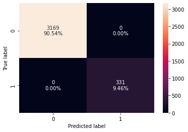

```python
confusion_matrix_sklearn(model, X_train, y_train)
```

#### Observations

- Model is able to perfectly classify all the data points on the training set.
- 0 errors on the training set, each sample has been classified correctly.
- As we know a decision tree will continue to grow and classify each data point correctly if no restrictions are applied as the trees will learn all the patterns in the training set.
- This generally leads to overfitting of the model as Decision Tree will perform well on the training set but will fail to replicate the performance on the test set.

#### Checking model performance on test set

```python
decision_tree_perf_test = model_performance_classification_sklearn(
    model, X_test, y_test
)
decision_tree_perf_test
```

|  | Accuracy | Recall | Precision | F1 |
| --- | --- | --- | --- | --- |
| 0 | 0.979333 | 0.879195 | 0.909722 | 0.894198 |

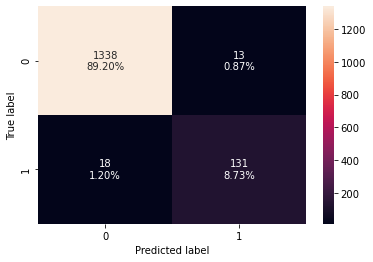

```python
confusion_matrix_sklearn(model, X_test, y_test)
```

#### Observation

- We observe disparity in the performance of model on training set and test set, which suggests that the model is overfitting.

## Visualizing the Decision Tree

```python
column_names = list(X.columns)
feature_names = column_names
print(feature_names)
```

```
['Age', 'Experience', 'Family_Size', 'Education', 'Securities_Account', 'CD_Account', 'Online_Banking', 'Other_CreditCard', 'Income_sqrt', 'CreditCard_Spending_sqrt', 'Mortgage_Holder', 'CA_Region_Inland_Empire', 'CA_Region_Los_Angeles_County', 'CA_Region_North_Coast', 'CA_Region_Northern_San_Joaqui…
```

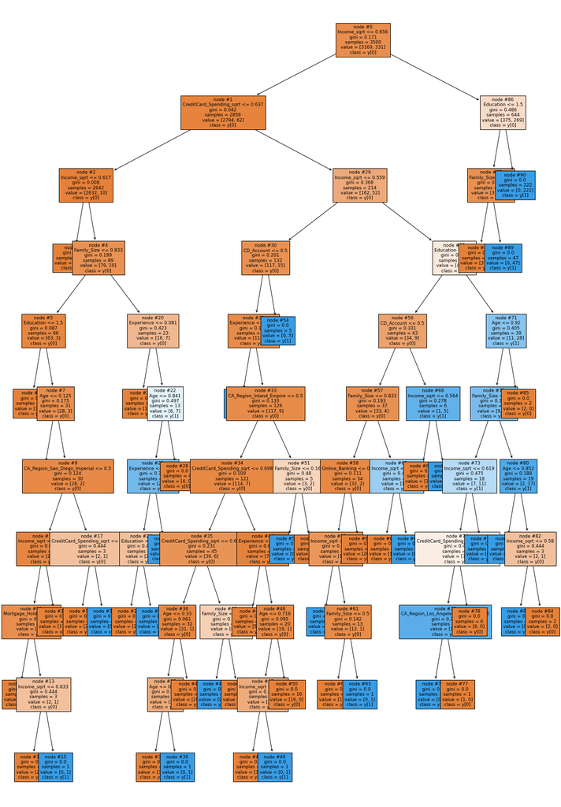

```python
plt.figure(figsize=(20, 30))

out = tree.plot_tree(
    model,
    feature_names=feature_names,
    filled=True,
    fontsize=9,
    node_ids=True,
    class_names=True,
)
for o in out:
    arrow = o.arrow_patch
    if arrow is not None:
        arrow.set_edgecolor("black")
        arrow.set_linewidth(1)
plt.show()
```

```python
# Text report showing the rules of a decision tree -

print(tree.export_text(model, feature_names=feature_names, show_weights=True))
```

```
|--- Income_sqrt <= 0.66
|   |--- CreditCard_Spending_sqrt <= 0.64
|   |   |--- Income_sqrt <= 0.62
|   |   |   |--- weights: [2553.00, 0.00] class: 0
|   |   |--- Income_sqrt >  0.62
|   |   |   |--- Family_Size <= 0.83
|   |   |   |   |--- Education <= 1.50
|   |   |   |   |   |--- weights: [35.00, 0.00] class: 0
|   |   |   |   |--- Education >  1.50
|   |   |   |   |   |--- Age <= 0.13
|   |   |   |   |   |   |--- weights: [0.00, 1.00] class: 1
|   |   |   |   |   |--- Age >  0.13
|   |   |   |   |   |   |--- CA_Region_San_Diego_Imperial <= 0.50
|   |   |   |   |   |   |   |--- Income_sqrt <= 0.64
|   |   |   |   |   |   |   |   |--- Mortgage_Holder <= 0.50
|   |   |   |   |   |   |   |   |   |--- weights: [7.00, 0.00] class: 0
|   |   |   |   |   |   |   |   |--- Mortgage_Holder >  0.50
|   |   |   |   |   |   |   |   |   |--- Income_sqrt <= 0.63
|   |   |   |   |   |   |   |   |   |   |--- weights: [2.00, 0.00] class: 0
|   |   |   |   |   |   |   |   |   |--- Income_sqrt >  0.63
|   |   |   |   |   |   |   |   |   |   |--- weights: [0.00, 1.00] class: 1
|   |   |   |   |   |   |   |--- Income_sqrt >  0.64
|   |   |   |   |   |   |   |   |--- weights: [17.00, 0.00] class: 0
|   |   |   |   |   |   |--- CA_Region_San_Diego_Imperial >  0.50
|   |   |   |   |   |   |   |--- CreditCard_Spending_sqrt <= 0.45
|   |   |   |   |   |   |   |   |--- weights: [2.00, 0.00] class: 0
|   |   |   |   |   |   |   |--- CreditCard_Spending_sqrt >  0.45
|   |   |   |   |   |   |   |   |--- weights: [0.00, 1.00] class: 1
|   |   |   |--- Family_Size >  0.83
|   |   |   |   |--- Experience <= 0.08
|   |   |   |   |   |--- weights: [10.00, 0.00] class: 0
|   |   |   |   |--- Experience >  0.08
|   |   |   |   |   |--- Age <= 0.84
|   |   |   |   |   |   |--- Experience <= 0.16
|   |   |   |   |   |   |   |--- Education <= 2.50
|   |   |   |   |   |   |   |   |--- weights: [2.00, 0.00] class: 0
|   |   |   |   |   |   |   |--- Education >  2.50
|   |   |   |   |   |   |   |   |--- weights: [0.00, 1.00] class: 1
|   |   |   |   |   |   |--- Experience >  0.16
|   |   |   |   |   |   |   |--- weights: [0.00, 6.00] class: 1
```

[output cut: 81 more lines]

```
|   |   |   |   |   |   |--- Age >  0.85
|   |   |   |   |   |   |   |--- Income_sqrt <= 0.58
|   |   |   |   |   |   |   |   |--- weights: [0.00, 1.00] class: 1
|   |   |   |   |   |   |   |--- Income_sqrt >  0.58
|   |   |   |   |   |   |   |   |--- weights: [2.00, 0.00] class: 0
|   |   |   |   |--- Age >  0.92
|   |   |   |   |   |--- weights: [2.00, 0.00] class: 0
|--- Income_sqrt >  0.66
|   |--- Education <= 1.50
|   |   |--- Family_Size <= 0.50
|   |   |   |--- weights: [375.00, 0.00] class: 0
|   |   |--- Family_Size >  0.50
|   |   |   |--- weights: [0.00, 47.00] class: 1
|   |--- Education >  1.50
|   |   |--- weights: [0.00, 222.00] class: 1
```

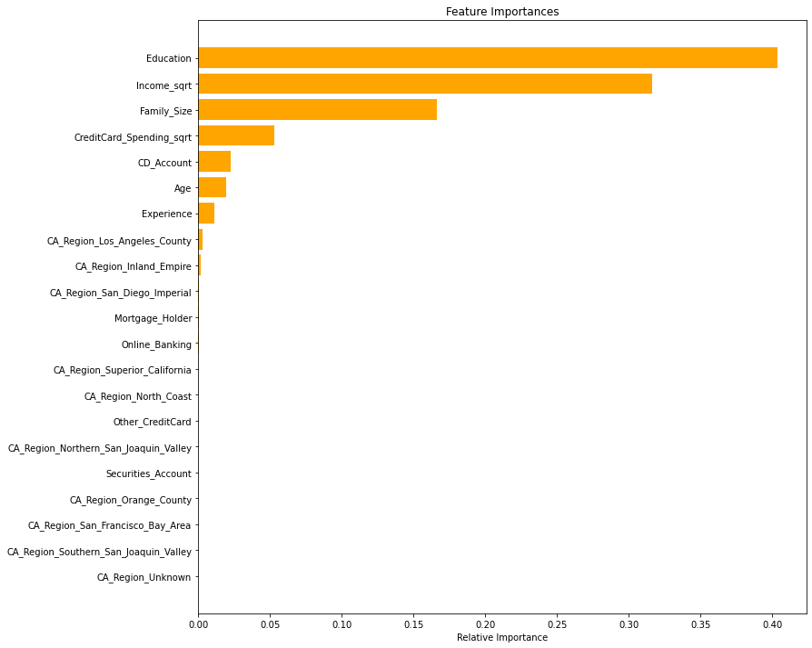

```python
importances = model.feature_importances_
indices = np.argsort(importances)

plt.figure(figsize=(12, 12))
plt.title("Feature Importances")
plt.barh(range(len(indices)), importances[indices], color="orange", align="center")
plt.yticks(range(len(indices)), [feature_names[i] for i in indices])
plt.xlabel("Relative Importance")
plt.show()
```

### Using GridSearch for Hyperparameter tuning of our tree model

- Let's see if we can improve our model performance even more.
- Model is giving good and generalized results on training and test set.

```python
# Choose the type of classifier.
estimator = DecisionTreeClassifier(random_state=1)

# Grid of parameters to choose from

parameters = {
    "max_depth": [np.arange(2, 50, 5), None],
    "criterion": ["entropy", "gini"],
    "splitter": ["best", "random"],
    "min_impurity_decrease": [0.00001, 0.0001, 0.001],
}

# Type of scoring used to compare parameter combinations
acc_scorer = make_scorer(precision_score)

# Run the grid search
grid_obj = GridSearchCV(estimator, parameters, scoring=acc_scorer, cv=5)
grid_obj = grid_obj.fit(X_train, y_train)

# Set the clf to the best combination of parameters
estimator = grid_obj.best_estimator_

# Fit the best algorithm to the data.
estimator.fit(X_train, y_train)
```

```
DecisionTreeClassifier(min_impurity_decrease=0.001, random_state=1)
```

#### Checking performance on training set

```python
decision_tree_tune_perf_train = model_performance_classification_sklearn(
    estimator, X_train, y_train
)
decision_tree_tune_perf_train
```

|  | Accuracy | Recall | Precision | F1 |
| --- | --- | --- | --- | --- |
| 0 | 0.989714 | 0.927492 | 0.962382 | 0.944615 |

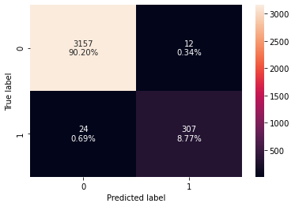

```python
confusion_matrix_sklearn(estimator, X_train, y_train)
```

#### Checking model performance on test set

```python
decision_tree_tune_perf_test = model_performance_classification_sklearn(
    estimator, X_test, y_test
)

decision_tree_tune_perf_test
```

|  | Accuracy | Recall | Precision | F1 |
| --- | --- | --- | --- | --- |
| 0 | 0.981333 | 0.879195 | 0.929078 | 0.903448 |

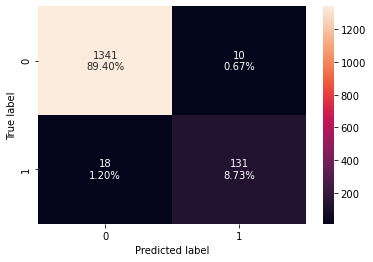

```python
confusion_matrix_sklearn(estimator, X_test, y_test)
```

- After hyperparameter tuning the model has performance has remained same and the model has become simpler.

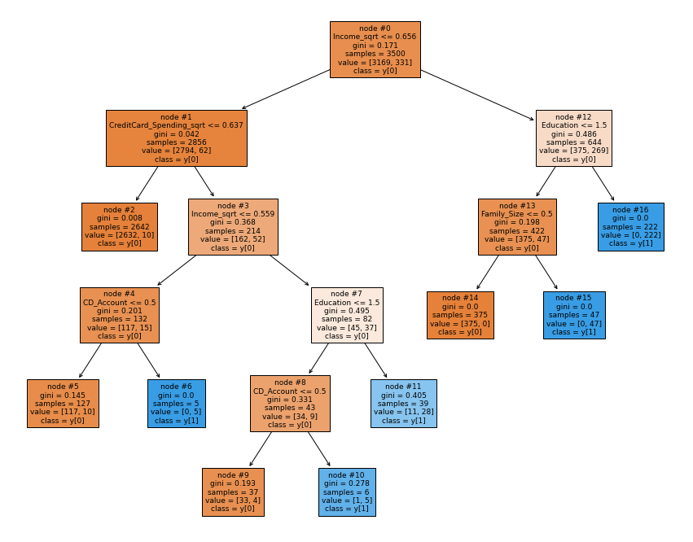

```python
plt.figure(figsize=(15, 12))

tree.plot_tree(
    estimator,
    feature_names=feature_names,
    filled=True,
    fontsize=9,
    node_ids=True,
    class_names=True,
)
plt.show()
```

```python
# Text report showing the rules of a decision tree -

print(tree.export_text(estimator, feature_names=feature_names, show_weights=True))
```

```
|--- Income_sqrt <= 0.66
|   |--- CreditCard_Spending_sqrt <= 0.64
|   |   |--- weights: [2632.00, 10.00] class: 0
|   |--- CreditCard_Spending_sqrt >  0.64
|   |   |--- Income_sqrt <= 0.56
|   |   |   |--- CD_Account <= 0.50
|   |   |   |   |--- weights: [117.00, 10.00] class: 0
|   |   |   |--- CD_Account >  0.50
|   |   |   |   |--- weights: [0.00, 5.00] class: 1
|   |   |--- Income_sqrt >  0.56
|   |   |   |--- Education <= 1.50
|   |   |   |   |--- CD_Account <= 0.50
|   |   |   |   |   |--- weights: [33.00, 4.00] class: 0
|   |   |   |   |--- CD_Account >  0.50
|   |   |   |   |   |--- weights: [1.00, 5.00] class: 1
|   |   |   |--- Education >  1.50
|   |   |   |   |--- weights: [11.00, 28.00] class: 1
|--- Income_sqrt >  0.66
|   |--- Education <= 1.50
|   |   |--- Family_Size <= 0.50
|   |   |   |--- weights: [375.00, 0.00] class: 0
|   |   |--- Family_Size >  0.50
|   |   |   |--- weights: [0.00, 47.00] class: 1
|   |--- Education >  1.50
|   |   |--- weights: [0.00, 222.00] class: 1
```

We are getting a more simplified tree after pre-pruning.

**Observations from decision tree after pre-pruning:**

- The first split in the decision tree model happens at the income level between customers making more than approx 100k/year (remembering that we are dealing with normalized values for income square root, 0.66 equates to approximately 75th percentile in the dataset's income distribution or 100k - reference below)
- The model predicts that, among customers who make equal to or less than approx 100k/year and have credit card spending over 2k/month (0.64 is the normalized value of credit card spending square root, which equates to approximately 65th percentile of the credit card spending distribution or 2k - reference below), if they make over 78k (please see reference below) and have a graduate and/or advanced/professional degree will accept the loan offer
- The model predicts that, among customers who make equal to or less than approx 100k/year and have credit card spending over 2k/month, if they make over 78k and have an undergraduate degree and a CD account at the bank will accept the loan offer
- The model predicts that, among customers make equal to or less than approx than 100k/year and have credit card spending over 2k/month, if they make below 78k/year and have a CD account at the bank will accept the loan offer
- The model predicts that a customer who has annual income greater than approx 100k and a graduate or advanced/professional degree will accept the personal loan offer.
- Customers making more than approx 100k/year without a graduate or advanced/professional degree but with family sizes greater than 2, the model predicts will accept the loan offer

**Reference**:

- Income_sqrt = 0.66 ≈ 75th percentile ≈ 100k
- Income_sqrt = 0.56 ≈ 60th percentile ≈ 78k
- CreditCard_Spending_sqrt = 0.64 ≈ 65th percentile ≈ 2k

### Cost Complexity Pruning

```python
clf = DecisionTreeClassifier(random_state=1)
path = clf.cost_complexity_pruning_path(X_train, y_train)
ccp_alphas, impurities = path.ccp_alphas, path.impurities
```

```python
pd.DataFrame(path)
```

|  | ccp_alphas | impurities |
| --- | --- | --- |
| 0 | 0.000000 | 0.000000 |
| 1 | 0.000183 | 0.000550 |
| 2 | 0.000188 | 0.001114 |
| 3 | 0.000258 | 0.001631 |
| 4 | 0.000277 | 0.002184 |
| 5 | 0.000285 | 0.002754 |
| 6 | 0.000359 | 0.003829 |
| 7 | 0.000381 | 0.004210 |
| 8 | 0.000381 | 0.004591 |
| 9 | 0.000381 | 0.004972 |
| 10 | 0.000476 | 0.005449 |
| 11 | 0.000490 | 0.005938 |
| 12 | 0.000508 | 0.006446 |
| 13 | 0.000582 | 0.007028 |
| 14 | 0.000642 | 0.007670 |
| 15 | 0.000686 | 0.008356 |
| 16 | 0.000692 | 0.011817 |
| 17 | 0.000750 | 0.014817 |
| 18 | 0.000792 | 0.017985 |
| 19 | 0.001552 | 0.019536 |
| 20 | 0.002333 | 0.021869 |
| 21 | 0.003024 | 0.024893 |
| 22 | 0.003294 | 0.028187 |
| 23 | 0.006473 | 0.034659 |
| 24 | 0.023866 | 0.058525 |
| 25 | 0.056365 | 0.171255 |

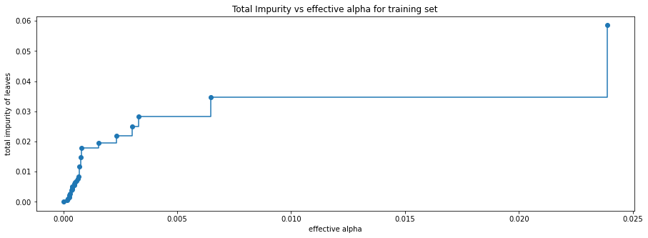

```python
fig, ax = plt.subplots(figsize=(15, 5))
ax.plot(ccp_alphas[:-1], impurities[:-1], marker="o", drawstyle="steps-post")
ax.set_xlabel("effective alpha")
ax.set_ylabel("total impurity of leaves")
ax.set_title("Total Impurity vs effective alpha for training set")
plt.show()
```

Next, we train a decision tree using the effective alphas. The last value in ccp_alphas is the alpha value that prunes the whole tree, leaving the tree, clfs[-1], with one node.

```python
clfs = []
for ccp_alpha in ccp_alphas:
    clf = DecisionTreeClassifier(random_state=1, ccp_alpha=ccp_alpha)
    clf.fit(X_train, y_train)
    clfs.append(clf)
print(
    "Number of nodes in the last tree is: {} with ccp_alpha: {}".format(
        clfs[-1].tree_.node_count, ccp_alphas[-1]
    )
)
```

```
Number of nodes in the last tree is: 1 with ccp_alpha: 0.056364969335601575
```

For the remainder, we remove the last element in clfs and ccp_alphas, because it is the trivial tree with only one node. Here we show that the number of nodes and tree depth decreases as alpha increases.

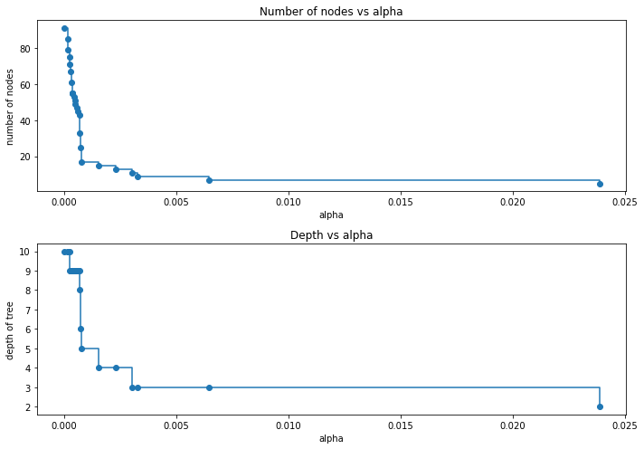

```python
clfs = clfs[:-1]
ccp_alphas = ccp_alphas[:-1]

node_counts = [clf.tree_.node_count for clf in clfs]
depth = [clf.tree_.max_depth for clf in clfs]
fig, ax = plt.subplots(2, 1, figsize=(10, 7))
ax[0].plot(ccp_alphas, node_counts, marker="o", drawstyle="steps-post")
ax[0].set_xlabel("alpha")
ax[0].set_ylabel("number of nodes")
ax[0].set_title("Number of nodes vs alpha")
ax[1].plot(ccp_alphas, depth, marker="o", drawstyle="steps-post")
ax[1].set_xlabel("alpha")
ax[1].set_ylabel("depth of tree")
ax[1].set_title("Depth vs alpha")
fig.tight_layout()
```

### Precision vs alpha for training and testing sets

```python
precision_train = []
for clf in clfs:
    pred_train = clf.predict(X_train)
    values_train = precision_score(y_train, pred_train)
    precision_train.append(values_train)
```

```python
precision_test = []
for clf in clfs:
    pred_test = clf.predict(X_test)
    values_test = precision_score(y_test, pred_test)
    precision_test.append(values_test)
```

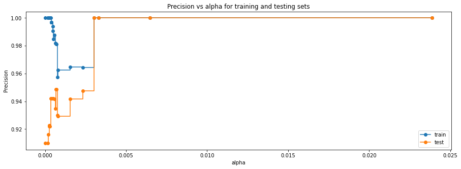

```python
fig, ax = plt.subplots(figsize=(15, 5))
ax.set_xlabel("alpha")
ax.set_ylabel("Precision")
ax.set_title("Precision vs alpha for training and testing sets")
ax.plot(ccp_alphas, precision_train, marker="o", label="train", drawstyle="steps-post")
ax.plot(ccp_alphas, precision_test, marker="o", label="test", drawstyle="steps-post")
ax.legend()
plt.show()
```

```python
# creating the model where we get highest train and test recall
index_best_model = np.argmax(precision_test)
best_model = clfs[index_best_model]
print(best_model)
```

```
DecisionTreeClassifier(ccp_alpha=0.003023521760901227, random_state=1)
```

#### Checking model performance on training set

```python
decision_tree_postpruned_perf_train = model_performance_classification_sklearn(
    best_model, X_train, y_train
)
decision_tree_postpruned_perf_train
```

|  | Accuracy | Recall | Precision | F1 |
| --- | --- | --- | --- | --- |
| 0 | 0.982286 | 0.812689 | 1.0 | 0.896667 |

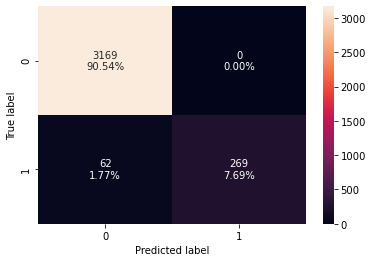

```python
confusion_matrix_sklearn(best_model, X_train, y_train)
```

#### Checking model performance on test set

```python
decision_tree_postpruned_perf_test = model_performance_classification_sklearn(
    best_model, X_test, y_test
)
decision_tree_postpruned_perf_test
```

|  | Accuracy | Recall | Precision | F1 |
| --- | --- | --- | --- | --- |
| 0 | 0.975333 | 0.751678 | 1.0 | 0.858238 |

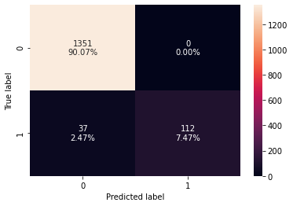

```python
confusion_matrix_sklearn(best_model, X_test, y_test)
```

### Visualizing the Decision Tree

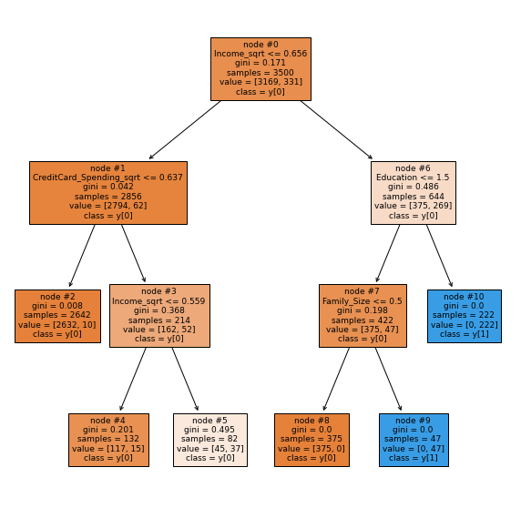

```python
plt.figure(figsize=(10, 10))

out = tree.plot_tree(
    best_model,
    feature_names=feature_names,
    filled=True,
    fontsize=9,
    node_ids=True,
    class_names=True,
)
for o in out:
    arrow = o.arrow_patch
    if arrow is not None:
        arrow.set_edgecolor("black")
        arrow.set_linewidth(1)
plt.show()
plt.show()
```

```python
# Text report showing the rules of a decision tree -

print(tree.export_text(best_model, feature_names=feature_names, show_weights=True))
```

```
|--- Income_sqrt <= 0.66
|   |--- CreditCard_Spending_sqrt <= 0.64
|   |   |--- weights: [2632.00, 10.00] class: 0
|   |--- CreditCard_Spending_sqrt >  0.64
|   |   |--- Income_sqrt <= 0.56
|   |   |   |--- weights: [117.00, 15.00] class: 0
|   |   |--- Income_sqrt >  0.56
|   |   |   |--- weights: [45.00, 37.00] class: 0
|--- Income_sqrt >  0.66
|   |--- Education <= 1.50
|   |   |--- Family_Size <= 0.50
|   |   |   |--- weights: [375.00, 0.00] class: 0
|   |   |--- Family_Size >  0.50
|   |   |   |--- weights: [0.00, 47.00] class: 1
|   |--- Education >  1.50
|   |   |--- weights: [0.00, 222.00] class: 1
```

**Observations from decision tree after post-pruning:**

- The model predicts that a customer who has annual income greater than approx 100k (reference below) and a graduate or advanced/professional degree will accept the personal loan offer
- Customers making more than approx 100k/year without a graduate or advanced/professional degree but with family sizes greater than 2, the model predicts will accept the loan offer

**Reference**:

- Income_sqrt = 0.66 ≈ 75th percentile ≈ 100k

```python
# importance of features in the tree building ( The importance of a feature is computed as the
# (normalized) total reduction of the 'criterion' brought by that feature. It is also known as the Gini importance )

print(
    pd.DataFrame(
        best_model.feature_importances_, columns=["Feature Importance"], index=X_train.columns
    ).sort_values(by="Feature Importance", ascending=False)
)
```

```
                                       Feature Importance
Education                                        0.448486
Income_sqrt                                      0.344228
Family_Size                                      0.163061
CreditCard_Spending_sqrt                         0.044225
Age                                              0.000000
CA_Region_North_Coast                            0.000000
CA_Region_Superior_California                    0.000000
CA_Region_Southern_San_Joaquin_Valley            0.000000
CA_Region_San_Francisco_Bay_Area                 0.000000
CA_Region_San_Diego_Imperial                     0.000000
CA_Region_Orange_County                          0.000000
CA_Region_Northern_San_Joaquin_Valley            0.000000
Mortgage_Holder                                  0.000000
CA_Region_Los_Angeles_County                     0.000000
CA_Region_Inland_Empire                          0.000000
Experience                                       0.000000
Other_CreditCard                                 0.000000
Online_Banking                                   0.000000
CD_Account                                       0.000000
Securities_Account                               0.000000
CA_Region_Unknown                                0.000000
```

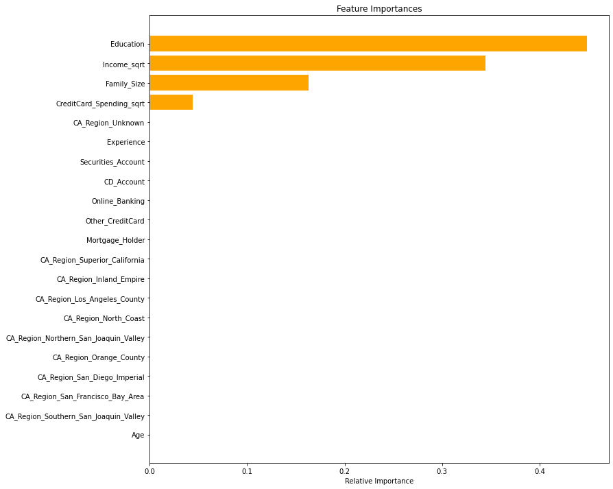

```python
importances = best_model.feature_importances_
indices = np.argsort(importances)

plt.figure(figsize=(12, 12))
plt.title("Feature Importances")
plt.barh(range(len(indices)), importances[indices], color="orange", align="center")
plt.yticks(range(len(indices)), [feature_names[i] for i in indices])
plt.xlabel("Relative Importance")
plt.show()
```

### Comparing all the decision tree models

```python
# training performance comparison

models_train_comp_df = pd.concat(
    [
        decision_tree_perf_train.T,
        decision_tree_tune_perf_train.T,
        decision_tree_postpruned_perf_train.T,
    ],
    axis=1,
)
models_train_comp_df.columns = [
    "Decision Tree sklearn",
    "Decision Tree (Pre-Pruning)",
    "Decision Tree (Post-Pruning)",
]
print("Training performance comparison:")
models_train_comp_df
```

```
Training performance comparison:
```

|  | Decision Tree sklearn | Decision Tree (Pre-Pruning) | Decision Tree (Post-Pruning) |
| --- | --- | --- | --- |
| Accuracy | 1.0 | 0.989714 | 0.982286 |
| Recall | 1.0 | 0.927492 | 0.812689 |
| Precision | 1.0 | 0.962382 | 1.000000 |
| F1 | 1.0 | 0.944615 | 0.896667 |

```python
# test performance comparison

models_test_comp_df = pd.concat(
    [
        decision_tree_perf_test.T,
        decision_tree_tune_perf_test.T,
        decision_tree_postpruned_perf_test.T,
    ],
    axis=1,
)
models_test_comp_df.columns = [
    "Decision Tree sklearn",
    "Decision Tree (Pre-Pruning)",
    "Decision Tree (Post-Pruning)",
]
print("Test set performance comparison:")
models_test_comp_df
```

```
Test set performance comparison:
```

|  | Decision Tree sklearn | Decision Tree (Pre-Pruning) | Decision Tree (Post-Pruning) |
| --- | --- | --- | --- |
| Accuracy | 0.979333 | 0.981333 | 0.975333 |
| Recall | 0.879195 | 0.879195 | 0.751678 |
| Precision | 0.909722 | 0.929078 | 1.000000 |
| F1 | 0.894198 | 0.903448 | 0.858238 |

#### Observations

- Decision tree with post-pruning is giving the highest precision on the test set - the model had 0 instances of misclassified positives or false positives
- The pre-prunning model still performs well in terms of precision while doing better than the post-prunning model in recall
- The tree with post pruning is not complex and easy to interpret

## Business Insights

- Education, income and family size (in that order) are the most important variables in determining if a customer will accept the personal loan offer
- The model indicates that, to minimize likelihood of extending loan offer to customers who will not accept it, the core group of customers to be targeted by the campaign should consist of customers with graduate and/or advanced/professional education (perhaps due to this group having incurred more personal debt over the course of their lives), income level over 100k (though the pre-pruning decision tree model predicts, so long as the customer's credit card spending is over 2k/month and customer has a CD account at the bank, that customer will accept the offer), and family size between 2 and 4 (4 being the maximum family size present in this dataset)
- Main criteria therefore to offer a personal loan should depend on three factors - income, education, and family size. Secondarily, the marketing team could take into account additional 2 factors: credit card spending and customer having a CD account at the bank.
- We recommend the marketing campaign to focus on these core customers in order to maximize conversion rates for the personal loan offer

## Optimizing Decision Tree Model with F1 scores

### Using GridSearch for Hyperparameter tuning of our tree model

- Let's see if we can improve our model performance even more.
- Model is giving good and generalized results on training and test set.

```python
# Choose the type of classifier.
estimator = DecisionTreeClassifier(random_state=1)

# Grid of parameters to choose from

parameters = {
    "max_depth": [np.arange(2, 50, 5), None],
    "criterion": ["entropy", "gini"],
    "splitter": ["best", "random"],
    "min_impurity_decrease": [0.0001, 0.001, 0.01],
}

# Type of scoring used to compare parameter combinations
acc_scorer = make_scorer(f1_score)

# Run the grid search
grid_obj = GridSearchCV(estimator, parameters, scoring=acc_scorer, cv=5)
grid_obj = grid_obj.fit(X_train, y_train)

# Set the clf to the best combination of parameters
estimator = grid_obj.best_estimator_

# Fit the best algorithm to the data.
estimator.fit(X_train, y_train)
```

```
DecisionTreeClassifier(min_impurity_decrease=0.001, random_state=1)
```

#### Checking performance on training set

```python
decision_tree_tune_perf_train_f1 = model_performance_classification_sklearn(
    estimator, X_train, y_train
)
decision_tree_tune_perf_train_f1
```

|  | Accuracy | Recall | Precision | F1 |
| --- | --- | --- | --- | --- |
| 0 | 0.989714 | 0.927492 | 0.962382 | 0.944615 |

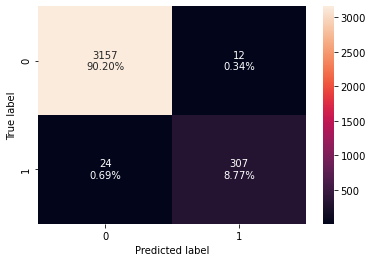

```python
confusion_matrix_sklearn(estimator, X_train, y_train)
```

#### Checking model performance on test set

```python
decision_tree_tune_perf_test_f1 = model_performance_classification_sklearn(
    estimator, X_test, y_test
)

decision_tree_tune_perf_test_f1
```

|  | Accuracy | Recall | Precision | F1 |
| --- | --- | --- | --- | --- |
| 0 | 0.981333 | 0.879195 | 0.929078 | 0.903448 |

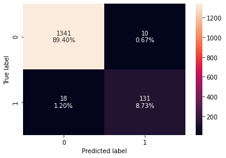

```python
confusion_matrix_sklearn(estimator, X_test, y_test)
```

#### Observations:

- No changes observed from model using precision score to compare parameter combinations

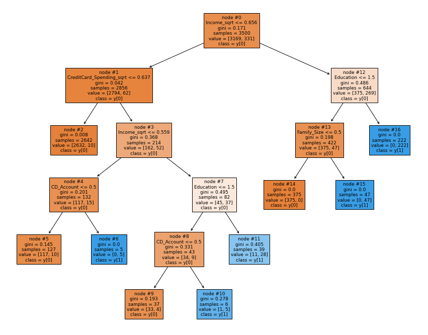

```python
plt.figure(figsize=(15, 12))

tree.plot_tree(
    estimator,
    feature_names=feature_names,
    filled=True,
    fontsize=9,
    node_ids=True,
    class_names=True,
)
plt.show()
```

```python
# Text report showing the rules of a decision tree -

print(tree.export_text(estimator, feature_names=feature_names, show_weights=True))
```

```
|--- Income_sqrt <= 0.66
|   |--- CreditCard_Spending_sqrt <= 0.64
|   |   |--- weights: [2632.00, 10.00] class: 0
|   |--- CreditCard_Spending_sqrt >  0.64
|   |   |--- Income_sqrt <= 0.56
|   |   |   |--- CD_Account <= 0.50
|   |   |   |   |--- weights: [117.00, 10.00] class: 0
|   |   |   |--- CD_Account >  0.50
|   |   |   |   |--- weights: [0.00, 5.00] class: 1
|   |   |--- Income_sqrt >  0.56
|   |   |   |--- Education <= 1.50
|   |   |   |   |--- CD_Account <= 0.50
|   |   |   |   |   |--- weights: [33.00, 4.00] class: 0
|   |   |   |   |--- CD_Account >  0.50
|   |   |   |   |   |--- weights: [1.00, 5.00] class: 1
|   |   |   |--- Education >  1.50
|   |   |   |   |--- weights: [11.00, 28.00] class: 1
|--- Income_sqrt >  0.66
|   |--- Education <= 1.50
|   |   |--- Family_Size <= 0.50
|   |   |   |--- weights: [375.00, 0.00] class: 0
|   |   |--- Family_Size >  0.50
|   |   |   |--- weights: [0.00, 47.00] class: 1
|   |--- Education >  1.50
|   |   |--- weights: [0.00, 222.00] class: 1
```

We are getting a more simplified tree after pre-pruning.

**Observations from decision tree after pre-pruning:**

- No changes observed from model using precision score to compare parameter combinations

### Cost Complexity Pruning

```python
clf = DecisionTreeClassifier(random_state=1)
path = clf.cost_complexity_pruning_path(X_train, y_train)
ccp_alphas, impurities = path.ccp_alphas, path.impurities
```

```python
pd.DataFrame(path)
```

|  | ccp_alphas | impurities |
| --- | --- | --- |
| 0 | 0.000000 | 0.000000 |
| 1 | 0.000183 | 0.000550 |
| 2 | 0.000188 | 0.001114 |
| 3 | 0.000258 | 0.001631 |
| 4 | 0.000277 | 0.002184 |
| 5 | 0.000285 | 0.002754 |
| 6 | 0.000359 | 0.003829 |
| 7 | 0.000381 | 0.004210 |
| 8 | 0.000381 | 0.004591 |
| 9 | 0.000381 | 0.004972 |
| 10 | 0.000476 | 0.005449 |
| 11 | 0.000490 | 0.005938 |
| 12 | 0.000508 | 0.006446 |
| 13 | 0.000582 | 0.007028 |
| 14 | 0.000642 | 0.007670 |
| 15 | 0.000686 | 0.008356 |
| 16 | 0.000692 | 0.011817 |
| 17 | 0.000750 | 0.014817 |
| 18 | 0.000792 | 0.017985 |
| 19 | 0.001552 | 0.019536 |
| 20 | 0.002333 | 0.021869 |
| 21 | 0.003024 | 0.024893 |
| 22 | 0.003294 | 0.028187 |
| 23 | 0.006473 | 0.034659 |
| 24 | 0.023866 | 0.058525 |
| 25 | 0.056365 | 0.171255 |

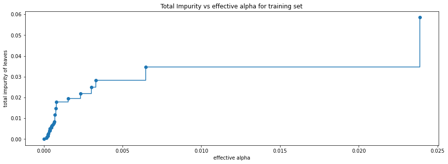

```python
fig, ax = plt.subplots(figsize=(15, 5))
ax.plot(ccp_alphas[:-1], impurities[:-1], marker="o", drawstyle="steps-post")
ax.set_xlabel("effective alpha")
ax.set_ylabel("total impurity of leaves")
ax.set_title("Total Impurity vs effective alpha for training set")
plt.show()
```

Next, we train a decision tree using the effective alphas. The last value in ccp_alphas is the alpha value that prunes the whole tree, leaving the tree, clfs[-1], with one node.

```python
clfs = []
for ccp_alpha in ccp_alphas:
    clf = DecisionTreeClassifier(random_state=1, ccp_alpha=ccp_alpha)
    clf.fit(X_train, y_train)
    clfs.append(clf)
print(
    "Number of nodes in the last tree is: {} with ccp_alpha: {}".format(
        clfs[-1].tree_.node_count, ccp_alphas[-1]
    )
)
```

```
Number of nodes in the last tree is: 1 with ccp_alpha: 0.056364969335601575
```

For the remainder, we remove the last element in clfs and ccp_alphas, because it is the trivial tree with only one node. Here we show that the number of nodes and tree depth decreases as alpha increases.

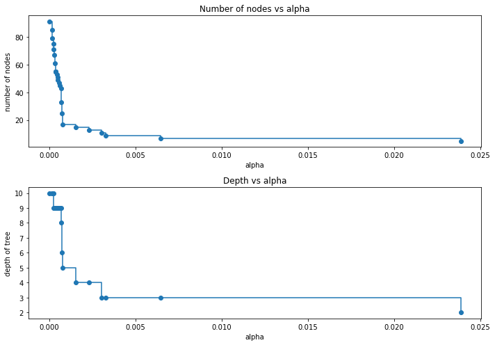

```python
clfs = clfs[:-1]
ccp_alphas = ccp_alphas[:-1]

node_counts = [clf.tree_.node_count for clf in clfs]
depth = [clf.tree_.max_depth for clf in clfs]
fig, ax = plt.subplots(2, 1, figsize=(10, 7))
ax[0].plot(ccp_alphas, node_counts, marker="o", drawstyle="steps-post")
ax[0].set_xlabel("alpha")
ax[0].set_ylabel("number of nodes")
ax[0].set_title("Number of nodes vs alpha")
ax[1].plot(ccp_alphas, depth, marker="o", drawstyle="steps-post")
ax[1].set_xlabel("alpha")
ax[1].set_ylabel("depth of tree")
ax[1].set_title("Depth vs alpha")
fig.tight_layout()
```

### F1 vs alpha for training and testing sets

```python
f1_train = []
for clf in clfs:
    pred_train = clf.predict(X_train)
    values_train = f1_score(y_train, pred_train)
    f1_train.append(values_train)
```

```python
f1_test = []
for clf in clfs:
    pred_test = clf.predict(X_test)
    values_test = f1_score(y_test, pred_test)
    f1_test.append(values_test)
```

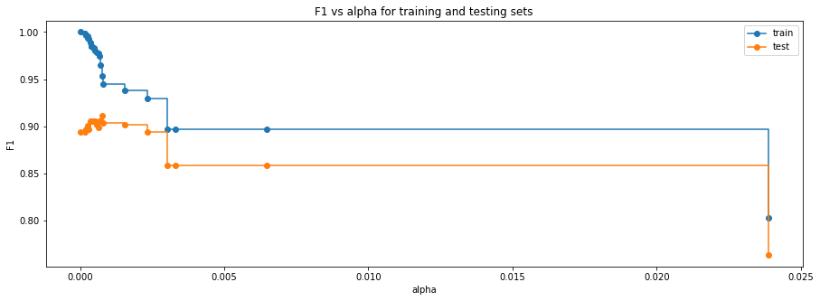

```python
fig, ax = plt.subplots(figsize=(15, 5))
ax.set_xlabel("alpha")
ax.set_ylabel("F1")
ax.set_title("F1 vs alpha for training and testing sets")
ax.plot(ccp_alphas, f1_train, marker="o", label="train", drawstyle="steps-post")
ax.plot(ccp_alphas, f1_test, marker="o", label="test", drawstyle="steps-post")
ax.legend()
plt.show()
```

```python
# creating the model where we get highest train and test recall
index_best_model = np.argmax(f1_test)
best_model = clfs[index_best_model]
print(best_model)
```

```
DecisionTreeClassifier(ccp_alpha=0.0007501170508689307, random_state=1)
```

#### Checking model performance on training set

```python
decision_tree_postpruned_perf_train_f1 = model_performance_classification_sklearn(
    best_model, X_train, y_train
)
decision_tree_postpruned_perf_train_f1
```

|  | Accuracy | Recall | Precision | F1 |
| --- | --- | --- | --- | --- |
| 0 | 0.991143 | 0.94864 | 0.957317 | 0.952959 |

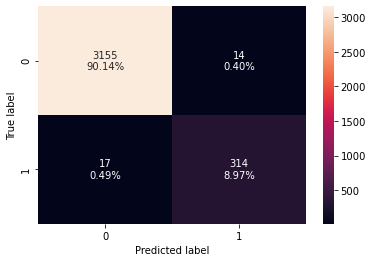

```python
confusion_matrix_sklearn(best_model, X_train, y_train)
```

#### Checking model performance on test set

```python
decision_tree_postpruned_perf_test_f1 = model_performance_classification_sklearn(
    best_model, X_test, y_test
)
decision_tree_postpruned_perf_test_f1
```

|  | Accuracy | Recall | Precision | F1 |
| --- | --- | --- | --- | --- |
| 0 | 0.982667 | 0.892617 | 0.93007 | 0.910959 |

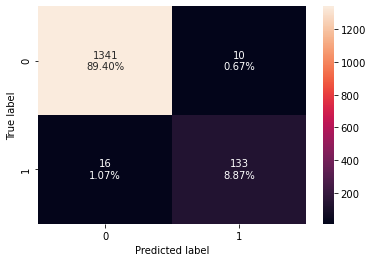

```python
confusion_matrix_sklearn(best_model, X_test, y_test)
```

### Visualizing the Decision Tree

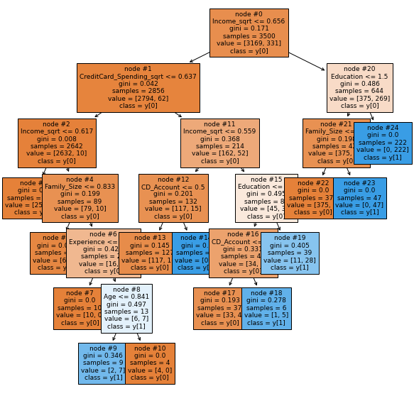

```python
plt.figure(figsize=(10, 10))

out = tree.plot_tree(
    best_model,
    feature_names=feature_names,
    filled=True,
    fontsize=9,
    node_ids=True,
    class_names=True,
)
for o in out:
    arrow = o.arrow_patch
    if arrow is not None:
        arrow.set_edgecolor("black")
        arrow.set_linewidth(1)
plt.show()
plt.show()
```

```python
# Text report showing the rules of a decision tree -

print(tree.export_text(best_model, feature_names=feature_names, show_weights=True))
```

```
|--- Income_sqrt <= 0.66
|   |--- CreditCard_Spending_sqrt <= 0.64
|   |   |--- Income_sqrt <= 0.62
|   |   |   |--- weights: [2553.00, 0.00] class: 0
|   |   |--- Income_sqrt >  0.62
|   |   |   |--- Family_Size <= 0.83
|   |   |   |   |--- weights: [63.00, 3.00] class: 0
|   |   |   |--- Family_Size >  0.83
|   |   |   |   |--- Experience <= 0.08
|   |   |   |   |   |--- weights: [10.00, 0.00] class: 0
|   |   |   |   |--- Experience >  0.08
|   |   |   |   |   |--- Age <= 0.84
|   |   |   |   |   |   |--- weights: [2.00, 7.00] class: 1
|   |   |   |   |   |--- Age >  0.84
|   |   |   |   |   |   |--- weights: [4.00, 0.00] class: 0
|   |--- CreditCard_Spending_sqrt >  0.64
|   |   |--- Income_sqrt <= 0.56
|   |   |   |--- CD_Account <= 0.50
|   |   |   |   |--- weights: [117.00, 10.00] class: 0
|   |   |   |--- CD_Account >  0.50
|   |   |   |   |--- weights: [0.00, 5.00] class: 1
|   |   |--- Income_sqrt >  0.56
|   |   |   |--- Education <= 1.50
|   |   |   |   |--- CD_Account <= 0.50
|   |   |   |   |   |--- weights: [33.00, 4.00] class: 0
|   |   |   |   |--- CD_Account >  0.50
|   |   |   |   |   |--- weights: [1.00, 5.00] class: 1
|   |   |   |--- Education >  1.50
|   |   |   |   |--- weights: [11.00, 28.00] class: 1
|--- Income_sqrt >  0.66
|   |--- Education <= 1.50
|   |   |--- Family_Size <= 0.50
|   |   |   |--- weights: [375.00, 0.00] class: 0
|   |   |--- Family_Size >  0.50
|   |   |   |--- weights: [0.00, 47.00] class: 1
|   |--- Education >  1.50
|   |   |--- weights: [0.00, 222.00] class: 1
```

**Observations from decision tree after post-pruning:**

- The main differences between F1 and precision models is that in the post-pruning F1 model, Experience and Age (which in the logistic regression model were dropped due to multicollinearity (Age) and p-value being greater than 0.05 (Experience)) enter the picture as predictors and the model gets more complex: the model predicts that customers who make between 100k and 85k/year with credit card spending equal to or less than 2k/month, with family size greater than 3, with over 4 years of professional experience and equal to or less than 60 years of age are predicted to accept the loan offer

**Reference**:

- Income_sqrt = 0.66 ≈ 75th percentile ≈ 100k
- Income_sqrt = 0.62 ≈ 70th percentile ≈ 85k
- CreditCard_Spending_sqrt = 0.64 = 65th percentile = 2k
- Family_Size = 0.83 ≈ 80th percentile ≈ 3 people
- Experience = 0.08 ≈ 10th percentile ≈ 4 years
- Age = 0.84 ≈ 90th percentile ≈ 60 years

```python
# importance of features in the tree building ( The importance of a feature is computed as the
# (normalized) total reduction of the 'criterion' brought by that feature. It is also known as the Gini importance )

print(
    pd.DataFrame(
        best_model.feature_importances_, columns=["Feature Importance"], index=X_train.columns
    ).sort_values(by="Feature Importance", ascending=False)
)
```

```
                                       Feature Importance
Education                                        0.438928
Income_sqrt                                      0.326024
Family_Size                                      0.156734
CreditCard_Spending_sqrt                         0.041376
CD_Account                                       0.024832
Age                                              0.006119
Experience                                       0.005986
CA_Region_Northern_San_Joaquin_Valley            0.000000
CA_Region_Superior_California                    0.000000
CA_Region_Southern_San_Joaquin_Valley            0.000000
CA_Region_San_Francisco_Bay_Area                 0.000000
CA_Region_San_Diego_Imperial                     0.000000
CA_Region_Orange_County                          0.000000
Mortgage_Holder                                  0.000000
CA_Region_North_Coast                            0.000000
CA_Region_Los_Angeles_County                     0.000000
CA_Region_Inland_Empire                          0.000000
Other_CreditCard                                 0.000000
Online_Banking                                   0.000000
Securities_Account                               0.000000
CA_Region_Unknown                                0.000000
```

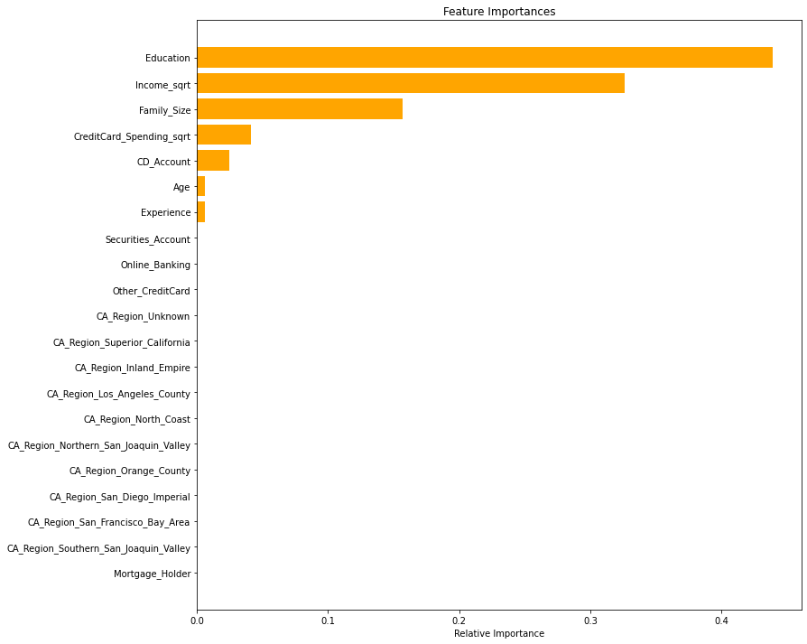

```python
importances = best_model.feature_importances_
indices = np.argsort(importances)

plt.figure(figsize=(12, 12))
plt.title("Feature Importances")
plt.barh(range(len(indices)), importances[indices], color="orange", align="center")
plt.yticks(range(len(indices)), [feature_names[i] for i in indices])
plt.xlabel("Relative Importance")
plt.show()
```

### Comparing all the decision tree models

```python
# training performance comparison

models_train_comp_df_f1 = pd.concat(
    [
        decision_tree_perf_train.T,
        decision_tree_tune_perf_train_f1.T,
        decision_tree_postpruned_perf_train_f1.T,
    ],
    axis=1,
)
models_train_comp_df_f1.columns = [
    "Decision Tree sklearn F1",
    "Decision Tree (Pre-Pruning) F1",
    "Decision Tree (Post-Pruning) F1",
]
print("Training performance comparison:")
models_train_comp_df_f1
```

```
Training performance comparison:
```

|  | Decision Tree sklearn F1 | Decision Tree (Pre-Pruning) F1 | Decision Tree (Post-Pruning) F1 |
| --- | --- | --- | --- |
| Accuracy | 1.0 | 0.989714 | 0.991143 |
| Recall | 1.0 | 0.927492 | 0.948640 |
| Precision | 1.0 | 0.962382 | 0.957317 |
| F1 | 1.0 | 0.944615 | 0.952959 |

```python
# test performance comparison

models_test_comp_df_f1 = pd.concat(
    [
        decision_tree_perf_test.T,
        decision_tree_tune_perf_test_f1.T,
        decision_tree_postpruned_perf_test_f1.T,
    ],
    axis=1,
)
models_test_comp_df_f1.columns = [
    "Decision Tree sklearn",
    "Decision Tree (Pre-Pruning) F1",
    "Decision Tree (Post-Pruning) F1",
]
print("Test set performance comparison:")
models_test_comp_df_f1
```

```
Test set performance comparison:
```

|  | Decision Tree sklearn | Decision Tree (Pre-Pruning) F1 | Decision Tree (Post-Pruning) F1 |
| --- | --- | --- | --- |
| Accuracy | 0.979333 | 0.981333 | 0.982667 |
| Recall | 0.879195 | 0.879195 | 0.892617 |
| Precision | 0.909722 | 0.929078 | 0.930070 |
| F1 | 0.894198 | 0.903448 | 0.910959 |

#### Observation

```python
# test performance comparison: Precision and F1 benchmarks

models_test_comp_df_f1_precision = pd.concat([
    log_reg_model_test_perf.T,
    decision_tree_tune_perf_test.T,
    decision_tree_postpruned_perf_test.T,
    decision_tree_tune_perf_test_f1.T,
    decision_tree_postpruned_perf_test_f1.T],
    axis=1,
)
models_test_comp_df_f1_precision.columns = [
    "Logistic Regression-0.50 Threshold",
    "Decision Tree (Pre-Pruning) Precision",
    "Decision Tree (Post-Pruning) Precision",
    "Decision Tree (Pre-Pruning) F1",
    "Decision Tree (Post-Pruning) F1"
]
print("Test set performance comparison:")
models_test_comp_df_f1_precision
```

```
Test set performance comparison:
```

|  | Logistic Regression-0.50 Threshold | Decision Tree (Pre-Pruning) Precision | Decision Tree (Post-Pruning) Precision | Decision Tree (Pre-Pruning) F1 | Decision Tree (Post-Pruning) F1 |
| --- | --- | --- | --- | --- | --- |
| Accuracy | 0.948667 | 0.981333 | 0.975333 | 0.981333 | 0.982667 |
| Recall | 0.610738 | 0.879195 | 0.751678 | 0.879195 | 0.892617 |
| Precision | 0.827273 | 0.929078 | 1.000000 | 0.929078 | 0.930070 |
| F1 | 0.702703 | 0.903448 | 0.858238 | 0.903448 | 0.910959 |

```python
row_precision = models_test_comp_df_f1_precision.iloc[2,0:5]
```

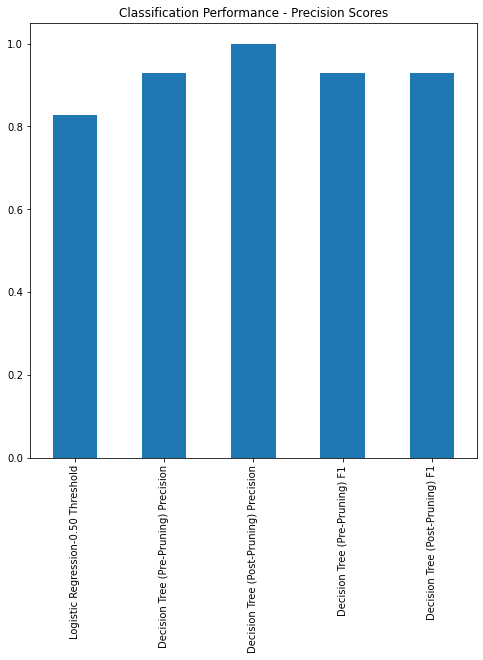

```python
row_precision.plot(kind='bar', figsize=(8,8),title="Classification Performance - Precision Scores")
```

```python
row_f1 = models_test_comp_df_f1_precision.iloc[3,0:5]
```

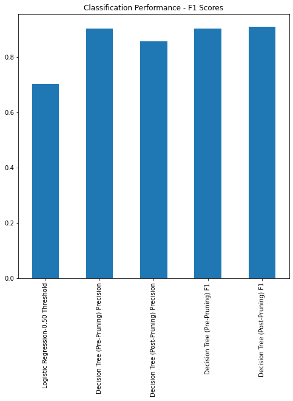

```python
row_f1.plot(kind='bar', figsize=(8,8),title="Classification Performance - F1 Scores")
```

#### Observations:

- The graphs show us a comparison of precision scores and F1 scores for the 0.5 threshold Logistic Regression model and all pre and post-pruning trees
- They show us that all models performed well
- The logistic regression model was the lowest performing, with 0.83 precision score and 0.70 F1 score
- The decision tree models were high performing, with precision scores of at least 0.93 and F1 scores of at least 0.85
- The findings indicate that all model tuning methods worked well at simplifying the original models while maintaining robust classification performance

# Insights and Final Business Recommendations

##### Insights:

After testing and tuning different classification models using Logistic Regression and Decision Trees we have come to key takeaways. The models paint the following profile of the ultimate AllLife Bank personal loan customer:

- Highly educated - educated over undergraduate level
- High income - annual income over 100k
- Family size consisting of 2 people or more
- High credit card spending - customers who spend over 2k/month are more likely to opt in for a personal loan
- CD Account - having a CD account at the bank also improves chances customer will accept loan offer

##### Recommendations to help the business grow:

Based on the models’ predictions, our recommendations are as follows:

- The core group to be targeted by the campaign should consist of customers with annual income of 100k or above, with education attainment over the undergraduate level (perhaps due to this group having incurred more educationrelated personal debt), and family sizes between 2 and 4 (4 being the maximum family size tested in this dataset)
- Campaigns developed to specially address the needs of these customers are predicted to yield higher conversion rates and gains for AllLife Bank
- Another recommendation would be to develop offers tailored to customers with the above characteristics and who are also opening a CD account at the bank or who are already existing CD account holders
- Extending personal loan offers geared toward high earning, highly educated customers who are married and/or have children can also lead to higher conversion rates for the campaign